# PG2

2022-11-25

```r
library(kableExtra)
```

# **Estudio de la cabellera de los estudiantes de UTEC**

## **1. Introducción**

### **Antecedentes**

Según Garnier (marca cosmética mundial desde 1995), nos dice que existe una gran variedad de diferencias entre el cabello de un varón con el de una mujer. El cabello de los hombres tiende a ser más grueso, además es más propenso a ser graso y tener caspa. Las mujeres por su parte, tienen el cabello más fino, lo que conlleva a que pueda ser más quebradizo y reseco. Pero, independientemente de que seas hombre o mujer, el cabello debe cuidarse adecuadamente para que esté completamente sano y evites enfermedades capilares como la caspa, la dermatitis entre otras.

Según algunos filósofos como Aristoteles sugiere que el cabello se formaba a través de los vapores impuros exhalados por los poros del cuerpo, estos residuos mediante un proceso se convertían en sangre y de esta manera crecía el cabello. Los hombres y las mujeres somos muy diferentes en todo, y el cabello no es la excepción. Existen diversas diferencias entre ambos cueros cabelludos. El cabello de los hombres tiende a ser más grueso, graso y tener caspa, por el contrario en caso de las mujeres el cabello tiende a ser más fino, lo que conlleva a ser más quebradizo y reseco. Por eso el cuidado del cabello, tanto del hombre como de la mujer depende de ciertos productos que utilizamos para nuestro lavado esto considerando el tipo de cabello que tengamos. En el mercado hay múltiples productos para que tu cabello esté saludable pero no todos se adaptan bien a tu tipo de cabello y a la necesidad que tengas, entonces en vez de cuidarlo, podrían dañarlo.

Según MedlinePlus (Un servicio de información en línea provisto por la Biblioteca Nacional de Medicina de los Estados Unidos), nos dice que uno de los cambios más común en las personas es el cambio de color en el cabello, ya que es uno de los signos más obvios del envejecimiento. El color del cabello se debe a un pigmento, llamado melanina, que producen los folículos pilosos. Los folículos pilosos son estructuras en la piel que producen y permiten el crecimiento del cabello. Con la edad, los folículos producen menos melanina y eso provoca las canas. El encanecimiento comienza con frecuencia hacia los 30 años de edad. Por ello, usar medicamentos y un shampoo adecuado, puede ayudar a prolongar el cambio de color.

### **Relevancia**

Determinar las características del cabello es mayor entre los estudiantes de UTEC y medir el impacto de los productos comerciales en cada uno de ellos con la finalidad poder producir y vender un shampoo especialmente diseñado para cada uno.

### **Factibilidad**

Para poder llevar a cabo el estudio, se decidió organizar de forma eficaz el proyecto. Por ello, se elaboró un diagrama de Gantt, el cual contiene las fechas de cada actividad realizada respetando el tiempo de entrega establecido.

#### **Planificación**

```r
library(ggplot2)
library(tidyr)
library(lubridate)
df <- read.csv("Gantt.csv")
```

```r
df <- data.frame(Tarea = c("Lluvia de ideas" , "Escoger tema" , "Herramienta de datos"          , "Recopilación de data", "Limpieza de data" , "Descriptores numéricos","Descriptores gráficos","Análisis probabilístico", "Modelos probabilísticos","Conclusiones y mejoras")
                 , Inicio = c("2022-08-24"      ,"2022-08-28"
                             ,"2022-08-31"        ,"2022-10-03"
                             ,"2022-10-10"        , "2022-10-17"
                             , "2022-10-25", "2022-11-12", "2022-11-14", "2022-11-16")

                 ,Fin = c("2022-08-27"         ,"2022-08-28"
                          ,"2022-09-08"        ,"2022-10-09"
                          ,"2022-10-16"        , "2022-10-24"
                          , "2022-10-27", "2022-11-24", "2022-11-25", "2022-11-25")
                 , Completo = c(TRUE, TRUE,TRUE, TRUE, TRUE, TRUE, TRUE,TRUE,TRUE,TRUE))
```

```r
library(ymd)
df$Inicio <- ymd(df$Inicio)
df$Fin <- ymd(df$Fin)
```

```r
df.melt <- df%>%
  tidyr::pivot_longer(col = c(Inicio,Fin))
```

```r
today <- Sys.Date()
```

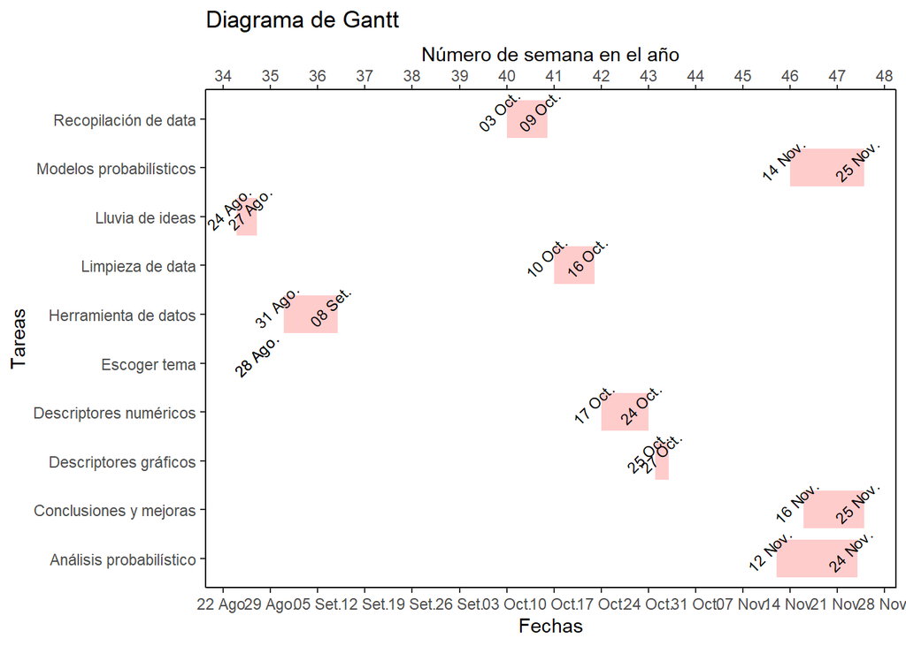

```r
pl <- ggplot(df.melt, aes(x = value, y = Tarea, colour = Completo ))
pl <- pl + geom_line( alpha = 0.2, size = 10)
pl <- pl + geom_text(aes(label = format(value, "%d %b")), vjust = -0.5, angle = 45, size = 3, color = "black")
pl <- pl +   theme_classic()
pl <- pl + geom_vline(xintercept = today, color = "red", size = 2, alpha = 0.5)
pl <- pl + labs(title = "Diagrama de Gantt")
pl <- pl + labs(x = "Date")
pl <- pl + labs(y = "Tareas")
pl <- pl + scale_color_manual(values = c("red", "blue"))
pl <- pl + theme(legend.position = "none")
pl <- pl + theme(panel.background = element_rect(color = "black"))
pl <- pl + scale_x_date(name = "Fechas"
                        ,  date_labels = "%d %b"
                        ,  date_breaks = "1 week"
                        , minor_breaks = "1 day"
                        ,  sec.axis =  dup_axis(name = "Número de semana en el año",labels = scales::date_format('%W')))
pl
```

## **2. Objetivos**

### **Objetivo general**

El objetivo principal de nuestro proyecto es saber acerca del cuidado y estado de la cabellera de los estudiantes de Utec, además se busca encontrar relaciones entre nuestras variables propuestas.

### **Objetivos específicos**

1. Determinar la preferencia de las personas respecto a los productos de cuidado del cabello.
2. Estimar la probabilidad de que las personas utilicen ciertos productos o herramientas para el cabello.
3. Determinar las diferencias del cuidado del cabello de acuerdo al género de las personas.
4. Determinar la salud del cabello en raleción a los productos y herramientas que utilizan.
5. Definir si existe alguna relación entre las caracteristicas del cabello, y los productos y herramientas que utilizan las personas.

### **Preguntas generales**

- ¿Qué productos y herramientas para el cabello suelen emplear los estudiantes del ciclo 2022-2 de UTEC?
- ¿Qué shampoo, productos y herramientas para el cabello presentan una mayor demanda por parte de los estudiantes de UTEC?
- ¿Cuáles son los ingredientes más frecuentes que están presentes en los productos que el alumnado de UTEC adquiere?
- ¿Cuáles son las características que predomina en la cabellera de los alumnos de UTEC?

## **3. Datos**

### **Proceso de recolección de datos**

Nuestro estudio fue realizado para poder encuestar el mínimo de observaciones requeridas con la finalidad de obtener información que represente a nuestra población. Para el presente trabajo se realizó una recolección de datos la cual fue ejecutada siguiendo un proceso en específico. En primer lugar, realizamos un formulario con preguntas sumamente exactas para así poder obtener el resultado deseado. Después, la estrategia que elegimos para obtener las encuestas en el menor tiempo posible fue la de comprar Ole ole, chupetes, galletas y chin chin para poder ofrecerlas a las personas que nos ayudarán llenando nuestro formulario. Posteriormente, pasamos a encuestar al mayor número de personas posibles. Luego caminamos del piso 1 al piso 11 para poder encontrar más personas y así ser más eficaces y lograr nuestro objetivo en el menor tiempo posible.

### **Población, muestra y muestreo**

- Población de estudio: Estudiantes de UTEC que se encuentran cursando el semestre 2022-2.
- Tamaño de la muestra: 257 encuestas
- Representatividad: Esta muestra representa la población de estudiantes de UTEC, debido a que supera la cantidad de estudiantes mínima requerida para el estudio. Por ello, las características de esta muestra se pueden generalizar a toda la población.
- Tipo de muestreo: No probabilístico intencional. Este estudio está siendo realizado en la universidad UTEC, a la cual pertenece el grupo 6 del curso Estadística y Probabilidades I

### **Variables**

| Pregunta formulada | Variable | Tipo de Variable | Restricciones |
| --- | --- | --- | --- |
| Edad | Edad | Numérica discreta | Solo números en años. |
| Género | Género | Categórica nominal | Pregunta cerrada (masculino, femenino y prefiero no decirlo). |
| Carrera | Carrera | Categórica nominal | Elegir entre opciones. |
| Ciclo | Ciclo | Categórica ordinal | Elegir entre números enteros con un rango de 1 a 10. |
| Escala a la que perteneces | Escala | Categórica ordinal | Elegir entre opciones A, B, C, D o D |
| Selecciona la longitud de tu cabello | Longitud | Categórica ordinal | Elegir entre opciones corto, mediano, largo o super largo. |
| Tipo de cabello | Tipo | Categórica nominal | Elegir opciones entre graso, mixto o seco. |
| ¿Qué tanto se lava el cabello? | LavaC | Categórica nominal | Elegir entre opciones de distintos intervalos |
| ¿Cuántos mililitros de shampoo usas al bañarte aproximadamente? | MiliS | Numérica discreta | Seleccionar entre el rango de las opciones. |
| Seleccione la temperatura del agua con la que se lava el cabello | Temperatura | Categórica ordinal | Elegir entre opciones fría, tibio, caliente o me es indiferente. |
| Introduce el tiempo en el que se demora secar tu cabello aproximadamente. | Tiempo | Numérica continua | Colocar el tiempo en minutos y solo el número |
| ¿Cuántas veces compras shampoo al mes? | VecesC | Numérica discreta | Colocar solo números enteros. |
| ¿Utilizas un shampoo con sulfatos? | Sulfatos | Categórica nominal | Seccionar entre las opciones sí, no u no sé. |
| ¿Utilizas shampoo con sal? | Sal | Categórica nominal | Seccionar entre las opciones sí, no u no sé. |
| ¿Utilizas shampoo cruelty free (libre de crueldad animal)? | Cruelfre | Categórica nominal | Seccionar entre las opciones sí, no u no sé. |
| ¿Cuál es el precio que pagas por un shampoo, frecuentemente? | Precio | Numérica continua | Colocar en soles y solo números enteros. |
| ¿Qué productos utilizas para el cabello? | ProduC | Categórica nominal | Se seleccionan múltiples opciones en un rango de 7 opciones |
| ¿Utilizas productos para el cabello con siliconas? | SiliC | Categórica nominal | Elegir entre las opciones sí, no u no sé. |
| ¿Qué herramientas de calor utilizas para el cabello? | HerraC | Categórica nominal | Se seleccionan múltiples opciones en un rango de 5 opciones. |
| ¿Quién compra el shampoo que utilizas? | Qcompra | Categórica nominal | Elegir entre las opciones yo, mamá, papá, amigo u otro familiar. |
| ¿Cuál es tu marca de preferencia? | Marca | Categórica nominal | Colocar el nombre de la marca en minúscula. |

## **4. Limpieza de datos**

Para poder iniciar con la limpieza de datos, primero debemos instalar y leer las siguientes librerías:

```r
library(readr)
library(dplyr)
library(tidyr)
library(stringr)
library(modeest)
library(car)
```

```r
library(ggplot2)
```

Ahora debemos cargar la base de datos

```r
CA <- read_csv("Encuesta_Estadistica_Grupo6.csv")
```

Analizando nuestra base de datos nos damos cuenta que tenemos dos columnas que no serán de utilidad para nuestro estudio, estas son “Marca temporal” Y “Dirección de correo”, es por eso que decidimos eliminarlas de la siguiente manera:

```r
CA <- CA[,c(3:23)]#En esta linea de código se están eliminando "Marca temporal" y "Dirección de correo electrónico"
```

Ahora con la función names podemos conocer los nombres de nuestra variables y con la función rename podemos modificarlas para facilitar su manejo.

```r
names(CA)
```

```
##  [1] "Género"
##  [2] "Edad (solo en números, ejemplo: 18, 20, 22, etc.)"
##  [3] "Carrera"
##  [4] "Ciclo"
##  [5] "Escala a la que perteneces en UTEC"
##  [6] "Selecciona la longitud de tu cabello"
##  [7] "Tipo de cabello"
##  [8] "¿Qué tanto se lava el cabello?"
##  [9] "¿Cuántos mililitros de shampoo usas al bañarte aproximadamente?"
## [10] "Seleccione la temperatura del agua con la que se lava el cabello"
## [11] "Introduce el tiempo en el que se demora secar tu cabello aproximadamente. (Colocar el tiempo en minutos y solo números, ejemplo: 15, 120, etc.)"
## [12] "¿Cuántas veces compras shampoo al mes? (Solo números, ejemplo: 1, 2, 3, etc.)"
## [13] "¿Utilizas un shampoo con sulfatos?"
## [14] "¿Utilizas shampoo con sal?"
## [15] "¿Utilizas shampoo cruelty free (libre de crueldad animal)?"
## [16] "¿Cuál es el precio que pagas por un shampoo, frecuentemente? (En soles y solo utilice números exactos, ejemplo: 15, 20, 30, etc.)"
## [17] "¿Qué productos utilizas para el cabello?"
## [18] "¿Utilizas productos para el cabello con siliconas?"
## [19] "¿Qué herramientas de calor utilizas para el cabello?"
## [20] "¿Quién compra el shampoo que utilizas?"
## [21] "¿Cuál es tu marca de preferencia? (Escríbelo todo en minúscula, ejemplo: sedal)"
```

```r
rename (CA,
        Genero = "Género",
        Edad =  "Edad (solo en números, ejemplo: 18, 20, 22, etc.)",
        Carrera = "Carrera",
        Ciclo = "Ciclo",
        Escala = "Escala a la que perteneces en UTEC",
        Longitud = "Selecciona la longitud de tu cabello",
        Tipo = "Tipo de cabello",
        LavaC = "¿Qué tanto se lava el cabello?",
        MiliS = "¿Cuántos mililitros de shampoo usas al bañarte aproximadamente?",
        Temperatura = "Seleccione la temperatura del agua con la que se lava el cabello",
        Tiempo =  "Introduce el tiempo en el que se demora secar tu cabello aproximadamente. (Colocar el tiempo en minutos y solo números, ejemplo: 15, 120, etc.)",
        VecesC = "¿Cuántas veces compras shampoo al mes? (Solo números, ejemplo: 1, 2, 3, etc.)",
        Sulfatos = "¿Utilizas un shampoo con sulfatos?",
        Sal =  "¿Utilizas shampoo con sal?",
        Cruelfre = "¿Utilizas shampoo cruelty free (libre de crueldad animal)?",
        Precio = "¿Cuál es el precio que pagas por un shampoo, frecuentemente? (En soles y solo utilice números exactos, ejemplo: 15, 20, 30, etc.)",
        ProduC = "¿Qué productos utilizas para el cabello?",
        SiliC = "¿Utilizas productos para el cabello con siliconas?",
        HerraC = "¿Qué herramientas de calor utilizas para el cabello?",
        Qcompra = "¿Quién compra el shampoo que utilizas?",
        Marca = "¿Cuál es tu marca de preferencia? (Escríbelo todo en minúscula, ejemplo: sedal)"
) -> CA
```

Ahora debemos de verificar la cantidad de datos completos e incompletos:

```r
sum(is.na(CA)) #cantidad de datos incompletos de DBT
```

```
## [1] 0
```

```r
sum(!is.na(CA)) # Los datos completos.
```

```
## [1] 5397
```

```r
sum(complete.cases(CA)) # Los casos completos de la base de datos.
```

```
## [1] 257
```

```r
sum(!complete.cases(CA)) # La cantidad de casos incompletos.
```

```
## [1] 0
```

Analizando nuestra base de datos nos dimos cuenta que en cinco variables encontramos algunos variables, procederemos a corregirlo: Primero usaremos unique para observar los errores de cada variable:

```r
unique(CA$Marca)
```

```
##   [1] "revlon"
##   [2] "savital"
##   [3] "P&G"
##   [4] "No tengo"
##   [5] "head y shoulders"
##   [6] "Tío Nacho"
##   [7] "Head and shoulders"
##   [8] "Salon in"
##   [9] "capilatis"
##  [10] "johnson's baby"
##  [11] "Cualquiera"
##  [12] "head & shoulders"
##  [13] "babaria"
##  [14] "baor"
##  [15] "Hs"
```

[output cut: 118 more lines]

```r
unique(CA$Edad)
```

```
##  [1] "21"                  "20"                  "18"
##  [4] "19"                  "24"                  "22"
##  [7] "17"                  "29"                  "32"
## [10] "diecinueve"          "26"                  "25"
## [13] "float n = 19.999999"
```

```r
unique(CA$Tiempo)
```

```
##  [1] "100"                              "6"
##  [3] "10"                               "30 min"
##  [5] "5"                                "A"
##  [7] "120"                              "30"
##  [9] "1 hora y media"                   "150"
## [11] "180"                              "20"
## [13] "60"                               "40"
## [15] "15"                               "90"
## [17] "45"                               "9"
## [19] "200"                              "1"
## [21] "240"                              "65"
## [23] "15 min"                           "80"
## [25] "5m"                               "3"
## [27] "25"                               "2"
## [29] "1 hora"                           "2.1"
## [31] "16"                               "3 horas"
## [33] "48"                               "12"
## [35] "s"                                "775"
## [37] "23"                               "19"
## [39] "50"                               "13"
## [41] "6 minutos"                        "0 horas ,4 minutos , 30 segundos"
## [43] "2 minutos"                        "4"
```

```r
unique(CA$VecesC)
```

```
##  [1] "1"            "0"            "V"            "3"            "2"
##  [6] "q"            "5"            "4"            "1 ves al mes" "56"
## [11] "0.3"          "19"           "0 -1.001"     "6"
```

```r
unique(CA$Precio)
```

```
##  [1] "80"       "21"       "15"       "30"       "25"       "45"
##  [7] "294"      "75"       "20"       "10"       "17"       "70"
## [13] "32"       "57"       "2"        "20-30"    "0"        "22"
## [19] "29"       "200"      "23 soles" "35"       "40"       "16"
## [25] "26"       "12"       "50"       "3"        "24"       "18"
## [31] "90"       "60"       "120"      "677"      "38"       "43"
## [37] "28"       "1.5"      "14"       "5,46"     "31"       "1"
## [43] "95"
```

Limpieza de la variable Precio:

```r
CA %>% mutate(Precio =
              ifelse(Precio == "23 soles", "23",
              ifelse(Precio == "1.5", "15" ,
              ifelse(Precio ==  "20-30", "25" ,
              ifelse(Precio ==  "5,46", "46" ,
              ifelse(Precio ==  "677", "77",
              ifelse(Precio ==  "0", NA,
                     Precio
              ))))))) ->CA
CA %>% count(Precio) #Con este comando se visualiza que la variable se ha corregido; también se puede utilizar unique(Periodo_Corregido
```

```
## # A tibble: 41 x 2
##    Precio     n
##    <chr>  <int>
##  1 1          1
##  2 10         5
##  3 12         2
##  4 120        1
##  5 14         1
##  6 15        33
##  7 16         1
##  8 17         3
##  9 18         3
## 10 2          1
## # i 31 more rows
```

Limpieza de la variable tiempo:

```r
unique(CA$Tiempo) #Permite conocer todas las formas que han respondido para la variable periodo
```

```
##  [1] "100"                              "6"
##  [3] "10"                               "30 min"
##  [5] "5"                                "A"
##  [7] "120"                              "30"
##  [9] "1 hora y media"                   "150"
## [11] "180"                              "20"
## [13] "60"                               "40"
## [15] "15"                               "90"
## [17] "45"                               "9"
## [19] "200"                              "1"
## [21] "240"                              "65"
## [23] "15 min"                           "80"
## [25] "5m"                               "3"
## [27] "25"                               "2"
## [29] "1 hora"                           "2.1"
## [31] "16"                               "3 horas"
## [33] "48"                               "12"
## [35] "s"                                "775"
## [37] "23"                               "19"
## [39] "50"                               "13"
## [41] "6 minutos"                        "0 horas ,4 minutos , 30 segundos"
## [43] "2 minutos"                        "4"
```

```r
CA %>% mutate(Tiempo =
        ifelse(Tiempo == "1 hora y media", "90",
        ifelse(Tiempo == "15 min", "15",
        ifelse(Tiempo == "5m", "5",
        ifelse(Tiempo == "1 hora", "60",
        ifelse(Tiempo == "6 minutos", "6",
        ifelse(Tiempo == "2 minutos", "2",
        ifelse(Tiempo == "30 min", "30",
        ifelse(Tiempo == "A", "10",
        ifelse(Tiempo == "2.1", "21",
        ifelse(Tiempo == "3 horas", "180",
        ifelse(Tiempo == "0 horas ,4 minutos , 30 segundos", "4",Tiempo
        )))))))))))) -> CA
CA %>% count(Tiempo) #Con este comando se visualiza que la variable se ha corregido; también se puede utilizar unique(Periodo_Corregido)
```

```
## # A tibble: 34 x 2
##    Tiempo     n
##    <chr>  <int>
##  1 1          2
##  2 10        36
##  3 100        2
##  4 12         1
##  5 120       17
##  6 13         1
##  7 15        43
##  8 150        4
##  9 16         2
## 10 180        5
## # i 24 more rows
```

Limpieza de la variable VecesC:

```r
CA %>% mutate(VecesC =
              ifelse(VecesC == "0 -1.001", "1" ,
              ifelse(VecesC == "0.3", "0" ,
              ifelse(VecesC == "1 ves al mes", "1" ,
              ifelse(VecesC == "q", "1" ,
              ifelse(VecesC ==  "V", "1",
                     VecesC
              ))))))->CA
CA %>% count(VecesC) #Con este comando se visualiza que la variable se ha corregido; también se puede utilizar unique(Periodo_Corregido
```

```
## # A tibble: 9 x 2
##   VecesC     n
##   <chr>  <int>
## 1 0          3
## 2 1        165
## 3 19         1
## 4 2         61
## 5 3         21
## 6 4          2
## 7 5          2
## 8 56         1
## 9 6          1
```

Limpieza de la variable Edad:

```r
CA %>% mutate(Edad=
              ifelse(Edad=="float n = 19.999999", "19",
              ifelse(Edad == "diecinueve", "19",
                        Edad
              )))->CA

CA %>% count(Edad)
```

```
## # A tibble: 11 x 2
##    Edad      n
##    <chr> <int>
##  1 17       47
##  2 18       61
##  3 19       60
##  4 20       46
##  5 21       28
##  6 22        9
##  7 24        2
##  8 25        1
##  9 26        1
## 10 29        1
## 11 32        1
```

Limpieza de la variable Marca:

```r
unique(CA$Marca) # Verificar las etiquetas de la variable Marca
```

```
##   [1] "revlon"
##   [2] "savital"
##   [3] "P&G"
##   [4] "No tengo"
##   [5] "head y shoulders"
##   [6] "Tío Nacho"
##   [7] "Head and shoulders"
##   [8] "Salon in"
##   [9] "capilatis"
##  [10] "johnson's baby"
##  [11] "Cualquiera"
##  [12] "head & shoulders"
##  [13] "babaria"
##  [14] "baor"
##  [15] "Hs"
```

[output cut: 118 more lines]

```r
CA %>% count(Marca) # Contabilizar cuántos han completado teniendo en cuenta las diferentes marcas
```

```
## # A tibble: 133 x 2
##    Marca                             n
##    <chr>                         <int>
##  1 .                                 1
##  2 Argan                             1
##  3 Clean                             1
##  4 Clear Men                         1
##  5 Clear men                         1
##  6 Cualquier shampoo da lo mismo     1
##  7 Cualquiera                        1
##  8 Cualquiera funciona               1
##  9 Dove                              5
## 10 ELVIVE                            1
## # i 123 more rows
```

```r
CA %>%  mutate(Marca =
      ifelse(Marca %in% c("revlon"),"Revlon",
      ifelse(Marca %in% c("capilatis"),"Capilatis",
      ifelse(Marca %in% c("savital", "Savitel"),"Savital",
      ifelse(Marca %in% c("P&G"),"Procter & Gamble",
      ifelse(Marca %in% c("head y shoulders","Head and shoulders","head & shoulders","head shoulder","Hs","Hs.","Head&shoulders","h&s","H&S","Head & Shoulders","head&shoulders","Head and Shoulder","Head and shoulder","Hys","H&s","Head n shoulders", "Head n shoulders", "Head and shower 🧼","Hys" ,"H&s","H S","HEAD&SHOULDERS","Head and Shoulders","Head &  shoulders", "Head Shoulder","HyS","hys","headandshoulders", "Head and shouders","Gead & shoulders","head shoulders" ,"H.shoulderr","Head&Shoulder","HEAD AND SHOULDERS","Headshoulder" , "hedan shoulder","H & S", "head and shoulders" ,"Hedanshowders","Head ans Shoulder","HS","Hy s","H y S"  ),"Head & Shoulders",
      ifelse(Marca %in% c("Salon in"), "Salon IN",
      ifelse(Marca %in% c("Tío Nacho","Tio nacho","Tionacho","Tío nacho","tío nacho","tio nacjo", "tio nacho", "Mi fiel Tío Nacho","Tio Nacho"), "Tío Nacho",
      ifelse(Marca %in% c("johnson's baby","Johnson's Baby", "Johnsons baby", "Johnson's Baby", "Jhonson’s baby"), "Johnson's Baby",
      ifelse(Marca %in% c("babaria", "Leo ?", "leo", "leo ", "leo ?"),"Barbaria",
      ifelse(Marca %in% c("baor", "Sagitatio", "Sagitario", "sagitatio"), "Baor",
      ifelse(Marca %in% c("sedal","Sedal, Elvive, Ego", "Sesal","SEDAL", "Sedal, Sabogal" ), "Sedal",
      ifelse(Marca %in% c("Pantene","pantene","Pannosetene"), "Pantene",
      ifelse(Marca %in% c("Kativa","kativa"),"Kativa",
      ifelse(Marca %in% c("elvive","Elvive",  "El vive - Loréal París","ELVIVE"),"Elvive",
      ifelse(Marca %in% c("Herbal Essences"),"Herbal Essences",
      ifelse(Marca %in% c("Clear men","Clear Men","Men","Clean"),"Clear Men",
      ifelse(Marca %in% c("Kumir"),"Kumir",
      ifelse(Marca %in% c("Ego","ego" ),"Ego",
      ifelse(Marca %in% c("ballerina"),"Ballerina",
      ifelse(Marca %in% c("recamier"),"Recamier",
      ifelse(Marca %in% c("L,bel","pantene"), "L'Bel",
      ifelse(Marca %in% c("dove", "Dove"),"Dove",
      ifelse(Marca %in% c("Jhonson & Johnson","Johnson"),"Johnson's",
      ifelse(Marca %in% c("Homen Natura","Natura", "natura"),"Natura",
      ifelse(Marca %in% c("Vitane"),"Vitane",
      ifelse(Marca %in% c("Medicasp"),"Medicasp",
      ifelse(Marca %in% c("geomen", "GEOMEN"),"Geomen",
      ifelse(Marca %in% c("garnier fructis","garnier"),"Garnier",
      ifelse(Marca %in% c("TIGI"),"TIGI",
      ifelse(Marca %in% c("herbal essences"),"Herbal Essences",
      ifelse(Marca %in% c("recamier"),"Recamier",
      ifelse(Marca %in% c("-", "", "No tengo", "Nose", "Ni yo la sé","No me fijo en uno", "Hm", "ogx", "No","No me acuerdo pero es de un emprendimiento","No tengo preferencias", "No recuerdo el nombre" ,"void","No se","No me acuerdo", "Argan","No sé", "Cualquiera funciona", "Cualquier shampoo da lo mismo", "a",".","Ukyff","H&m", "Hola","Sebastian" ), NA,
             Marca
             ))))))))))))))))))))))))))))))))) -> CA
CA %>% count(Marca)
```

```
## # A tibble: 37 x 2
##    Marca          n
##    <chr>      <int>
##  1 Ballerina      1
##  2 Baor           2
##  3 Barbaria       1
##  4 Capilatis      1
##  5 Clear Men      4
##  6 Cualquiera     1
##  7 Dove           6
##  8 Ego           10
##  9 Elvive         5
## 10 Eucerin        1
## # i 27 more rows
```

También observamos que tenemos dos variables con alternativas múltiples, es por eso que las separaremos con la función grep. Empezamos con la Variable ProduC:

```r
CA$Acondicionador <- NA
CA$Mascarilla_para_el_cabello <- NA
CA$Gel <- NA
CA$Crema_para_peinar <- NA
CA$Serum<- NA
CA$otros <- NA
CA$No_utilizo <- NA


CA$Acondicionador[grep("Acondiconador", CA$ProduC)] <- "Sí"
CA$Mascarilla_para_el_cabello[grep("Mascarilla para el cabello", CA$ProduC)] <- "Sí"
CA$Gel[grep("Gel", CA$ProduC)] <- "Sí"
CA$Crema_para_peinar[grep("Crema para peinar", CA$ProduC )] <- "Sí"
CA$Serum[grep("Serum",CA$ProduC)] <- "Sí"
CA$otros[grep("otros", CA$ProduC)] <- "Sí"
CA$No_utilizo[grep("No utilizo", CA$ProduC)] <- "Sí"

CA$Acondicionador[is.na(CA$Acondicionador)] <- "No"
CA$Mascarilla_para_el_cabello[is.na(CA$Mascarilla_para_el_cabello)] <- "No"
CA$Gel[is.na(CA$Gel)] <- "No"
CA$Crema_para_peinar[is.na(CA$Crema_para_peinar )] <- "No"
CA$Serum[is.na(CA$Serum)] <- "No"
CA$otros[is.na(CA$otros)] <- "No"
CA$No_utilizo[is.na(CA$No_utilizo)] <- "No"
```

Seguimos con la variable HerraC:

```r
CA$Plancha <- NA
CA$Secador <- NA
CA$Rizador <- NA
CA$OtrasHerr <- NA
CA$No_utilizoHerr <- NA


CA$Plancha[grep("Plancha", CA$HerraC)] <- "Sí"
CA$Secador[grep("Secador", CA$HerraC)] <- "Sí"
CA$Rizador[grep("Rizador", CA$HerraC)] <- "Sí"
CA$OtrasHerr[grep("Otros", CA$HerraC)] <- "Sí"
CA$No_utilizoHerr[grep("No utilizo", CA$HerraC)] <- "Sí"

CA$Plancha[is.na(CA$Plancha)] <- "No"
CA$Secador[is.na(CA$Secador)] <- "No"
CA$Rizador[is.na(CA$Rizador)] <- "No"
CA$OtrasHerr[is.na(CA$OtrasHerr)] <- "No"
CA$No_utilizoHerr[is.na(CA$No_utilizoHerr)] <- "No"
```

Observamos con la función str que R no reconoce a estas varibles como numéricas, entonces usamos la función as.numeric para convertirlas en numéricas:

```r
str(CA)
```

```
## tibble [257 x 33] (S3: tbl_df/tbl/data.frame)
##  $ Genero                    : chr [1:257] "Femenino" "Masculino" "Masculino" "Femenino" ...
##  $ Edad                      : chr [1:257] "21" "21" "21" "20" ...
##  $ Carrera                   : chr [1:257] "Bioingeniería" "Ing. Civil" "Ing. Industrial" "Ing. Civil" ...
##  $ Ciclo                     : num [1:257] 4 3 4 3 3 6 4 4 4 2 ...
##  $ Escala                    : chr [1:257] "E" "E" "E" "E" ...
##  $ Longitud                  : chr [1:257] "Mediano" "Corto" "Corto" "Largo" ...
##  $ Tipo                      : chr [1:257] "Graso" "Mixto" "Mixto" "Seco" ...
##  $ LavaC                     : chr [1:257] "Interdiario" "Diario" "Interdiario" "Interdiario" ...
##  $ MiliS                     : num [1:257] 1 3 3 5 3 5 5 1 4 2 ...
##  $ Temperatura               : chr [1:257] "Tibia" "Fría" "Fría" "Caliente" ...
##  $ Tiempo                    : chr [1:257] "100" "6" "10" "30" ...
##  $ VecesC                    : chr [1:257] "1" "1" "1" "1" ...
##  $ Sulfatos                  : chr [1:257] "No" "No sé" "No sé" "No" ...
##  $ Sal                       : chr [1:257] "No" "No sé" "No sé" "No" ...
```

[output cut: 19 more lines]

```r
CA$Edad<-as.numeric(CA$Edad)
```

```r
CA$Precio<-as.numeric(CA$Precio)
```

```r
CA$VecesC<-as.numeric(CA$VecesC)
```

```r
CA$Tiempo<-as.numeric(CA$Tiempo)
```

## **5. Descriptores numéricos**

```r
summary(CA$Edad)
```

```
##    Min. 1st Qu.  Median    Mean 3rd Qu.    Max.
##   17.00   18.00   19.00   19.08   20.00   32.00
```

### Tablas de doble entrada:

Se evalúa la preferencia del género masculino y femenino respecto a la temperatura con la que se lavan el cabello. Se puede visualizar que la mayoria de estudiantes masculinos encuestados prefieren lavarse el cabello con agua fría. Por otro lado, las estudiantes femeninas encuestadas, prefieren lavarse el cabello con agua tibia.

```r
table(CA$Temperatura,CA$Genero)
```

```
##
##                     Femenino Masculino
##   Caliente                18        40
##   Fría                    22        63
##   Me es indiferente        3        18
##   Tibia                   45        48
```

### Tabla desagregada (tres variables)

Se evalúa el nivel de temperatura a la que se lavan el cabello y la cantidad de veces que realizan dicha acción respecto al género estudiantes de UTEC. Los estudiantes masculinos que se lavan el cabello con agua caliente, en su mayoria prefieren lavarse el cabello diariamente. La mayoria de estudiantes pertenecientes al género femenino se lavan el cabello interdiariamente con agua tibia, al igual que la mayoria de estudiantes masculinos con la diferencia de que prefieren hacerlo con agua fría.

```r
table(CA$Genero,CA$LavaC,CA$Temperatura)
```

```
## , ,  = Caliente
##
##
##             Diario Dos veces a la semana Interdiario Una vez a la semana
##   Femenino       3                     3          12                   0
##   Masculino     22                     2          16                   0
##
## , ,  = Fría
##
##
##             Diario Dos veces a la semana Interdiario Una vez a la semana
##   Femenino       4                     3          14                   1
##   Masculino     26                     6          30                   1
##
## , ,  = Me es indiferente
##
##
##             Diario Dos veces a la semana Interdiario Una vez a la semana
##   Femenino       0                     2           1                   0
##   Masculino      6                     3           8                   1
##
## , ,  = Tibia
##
##
##             Diario Dos veces a la semana Interdiario Una vez a la semana
##   Femenino       8                     5          31                   1
##   Masculino     27                     5          15                   1
```

## **6. Descriptores gráficos**

##### Tabla de género

```r
tablaGenero<-CA %>% count(Genero)
tablaGenero<-tablaGenero %>% mutate(fr=round(n/(length(CA$`Nombres y Apellidos`)),4))
tablaGenero<-tablaGenero%>% mutate(fp=100*tablaGenero$fr)
tablaGenero
```

```
## # A tibble: 2 x 4
##   Genero        n    fr    fp
##   <chr>     <int> <dbl> <dbl>
## 1 Femenino     88   Inf   Inf
## 2 Masculino   169   Inf   Inf
```

```r
library(readr)
library(dplyr)
library(modeest)
library(RColorBrewer)
```

```r
library(stringr)
library(ggplot2)
```

*Observación*

Se obtuvo mayor cantidad de respuestas por parte de estudiantes del género masculino

#### Edad:

Se raliza una representación gráfica sobre las edades que poseen los estudiantes de UTEC que fueron encuestados y forman parte de nuestra muestra.

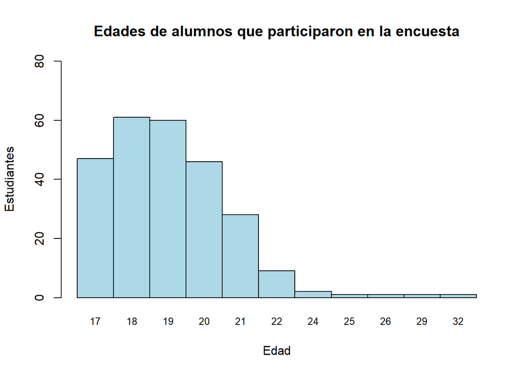

```r
barplot(table(CA$Edad), main = "Edades de alumnos que participaron en la encuesta", ylab = "Estudiantes", xlab = "Edad", col="lightblue",ylim = c(0,80),space = 0,cex.names = 0.8)
```

*Observaciones*

- En nuestra muestra se presenta mayor cantidad de personas de 18 y 19 años de edad.
- Se presenta mayor número de respuestas del género masculino.

##### Tabla de escala

```r
tablaEscala<-CA %>% count(Escala)
tablaEscala<-tablaEscala %>% mutate(fr=round(n/(length(CA$`Nombres y Apellidos`)),30))
tablaEscala<-tablaEscala%>% mutate(fp=100*tablaEscala$fr)
tablaEscala
```

```
## # A tibble: 5 x 4
##   Escala     n    fr    fp
##   <chr>  <int> <dbl> <dbl>
## 1 A         11   Inf   Inf
## 2 B         19   Inf   Inf
## 3 C         16   Inf   Inf
## 4 D         47   Inf   Inf
## 5 E        164   Inf   Inf
```

```r
library(ggplot2)
library(ggthemes)
library(scales)
library(dplyr)
```

### Características del cabello

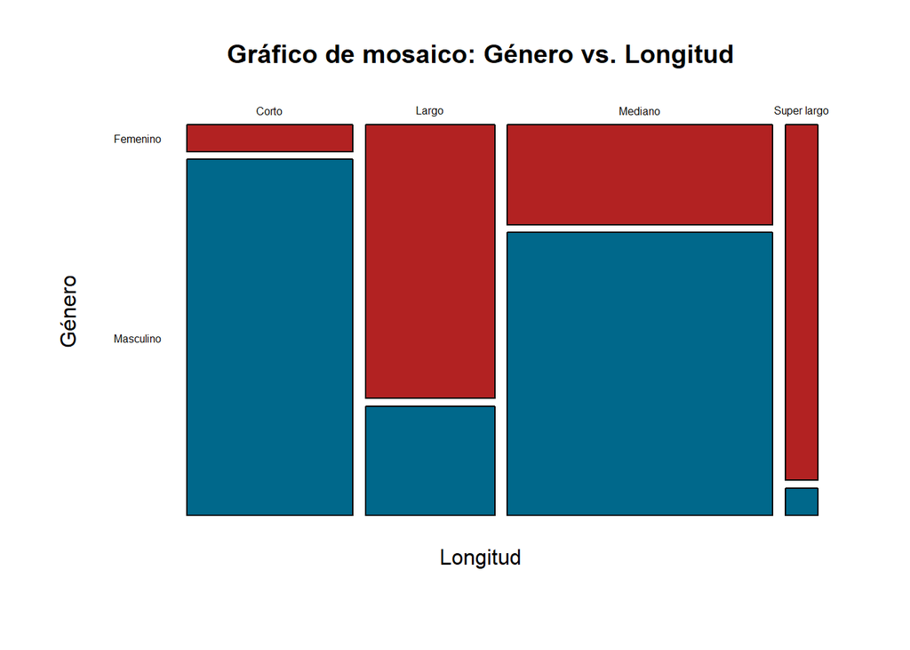

```r
mosaicplot(CA$Longitud~CA$Genero,col=c("firebrick","deepskyblue4"),
           main="Gráfico de mosaico: Género vs. Longitud",
           xlab="Longitud",
           ylab="Género",
           cex.axis=0.5,
           las=1)
```

*Observaciones*

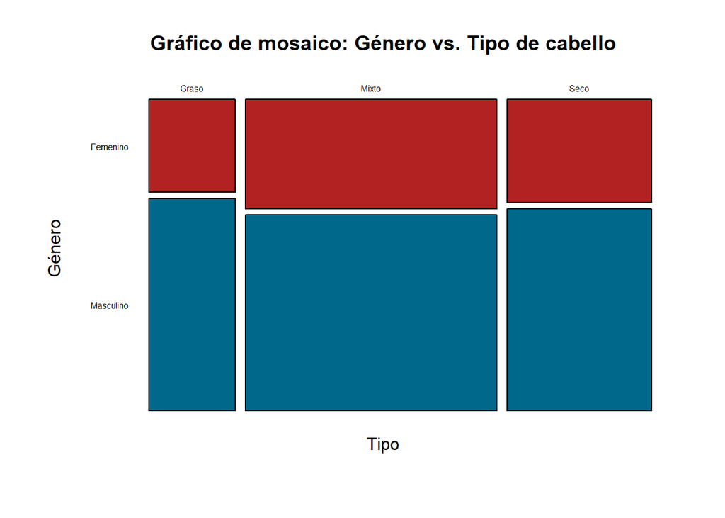

```r
mosaicplot(CA$Tipo~CA$Genero,col=c("firebrick","deepskyblue4"),
           main="Gráfico de mosaico: Género vs. Tipo de cabello",
           xlab="Tipo",
           ylab="Género",
           cex.axis=0.5,
           las=1)
```

#### Tabla desagregadas (tres variables)

```r
table(CA$Genero,CA$LavaC,CA$Temperatura)
```

```
## , ,  = Caliente
##
##
##             Diario Dos veces a la semana Interdiario Una vez a la semana
##   Femenino       3                     3          12                   0
##   Masculino     22                     2          16                   0
##
## , ,  = Fría
##
##
##             Diario Dos veces a la semana Interdiario Una vez a la semana
##   Femenino       4                     3          14                   1
##   Masculino     26                     6          30                   1
##
## , ,  = Me es indiferente
##
##
##             Diario Dos veces a la semana Interdiario Una vez a la semana
##   Femenino       0                     2           1                   0
##   Masculino      6                     3           8                   1
##
## , ,  = Tibia
##
##
##             Diario Dos veces a la semana Interdiario Una vez a la semana
##   Femenino       8                     5          31                   1
##   Masculino     27                     5          15                   1
```

Se evalúa el nivel de temperatura a la que se lavan el cabello y la cantidad de veces que realizan dicha acción respecto al género estudiantes de UTEC. Los estudiantes masculinos que se lavan el cabello con agua caliente, en su mayoria prefieren lavarse el cabello diariamente. La mayoria de estudiantes pertenecientes al género femenino se lavan el cabello interdiariamente con agua tibia, al igual que la mayoria de estudiantes masculinos con la diferencia de que prefieren hacerlo con agua fría.

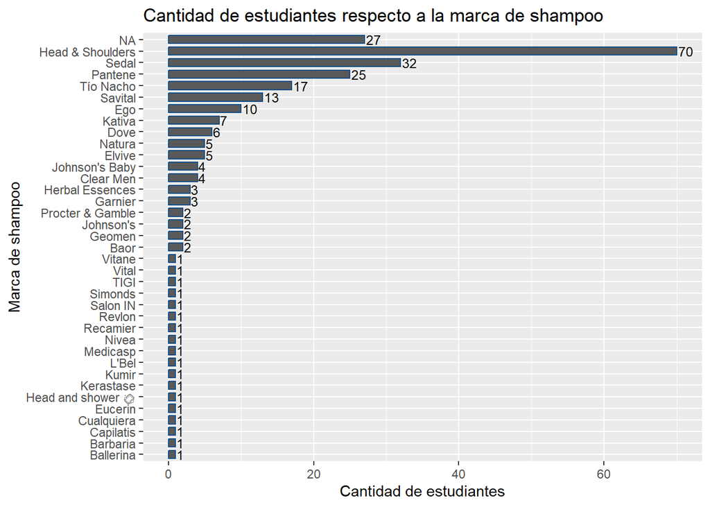

*Observaciones* * El shampoo con mayor demanda por parte de los utecsinos es Head & Shoulders.

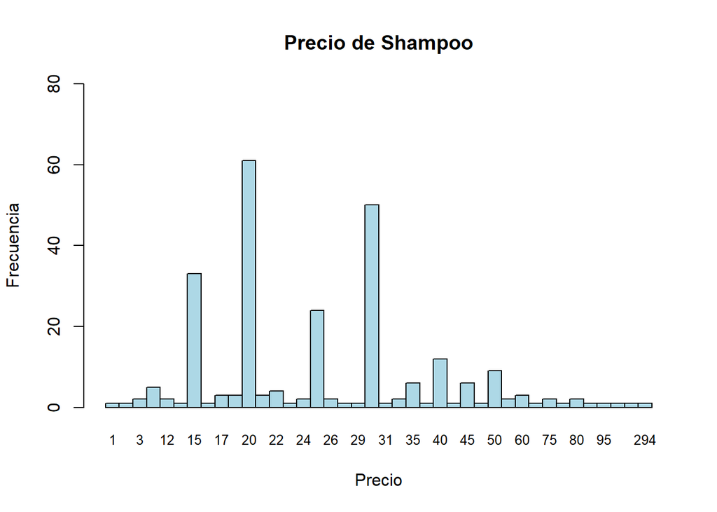

```r
barplot(table(CA$Precio), main = "Precio de Shampoo", ylab = "Frecuencia", xlab = "Precio", col="lightblue",ylim = c(0,80),space = 0,cex.names = 0.8)
```

```r
attach(CA)
names(CA)
```

```
##  [1] "Genero"                     "Edad"
##  [3] "Carrera"                    "Ciclo"
##  [5] "Escala"                     "Longitud"
##  [7] "Tipo"                       "LavaC"
##  [9] "MiliS"                      "Temperatura"
## [11] "Tiempo"                     "VecesC"
## [13] "Sulfatos"                   "Sal"
## [15] "Cruelfre"                   "Precio"
## [17] "ProduC"                     "SiliC"
## [19] "HerraC"                     "Qcompra"
## [21] "Marca"                      "Acondicionador"
## [23] "Mascarilla_para_el_cabello" "Gel"
## [25] "Crema_para_peinar"          "Serum"
## [27] "otros"                      "No_utilizo"
## [29] "Plancha"                    "Secador"
## [31] "Rizador"                    "OtrasHerr"
## [33] "No_utilizoHerr"
```

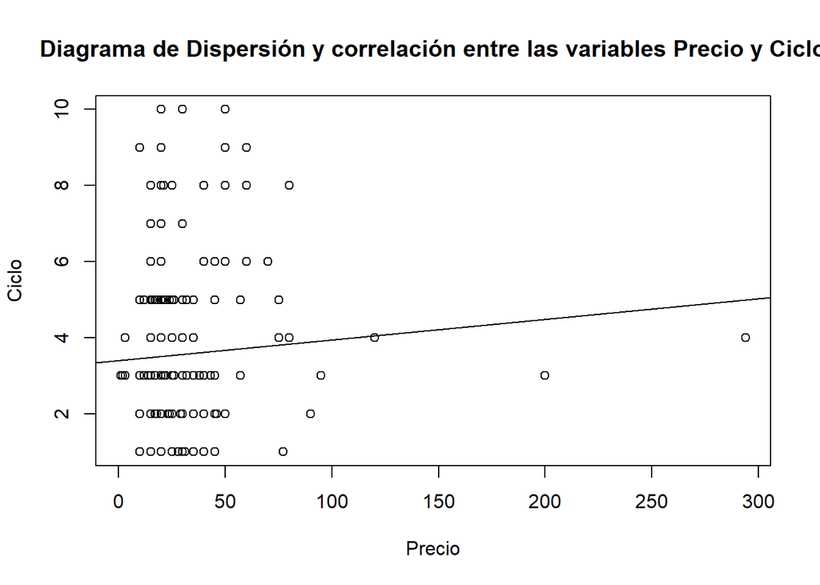

```r
plot(Ciclo ~ Precio, main="Diagrama de Dispersión y correlación entre las variables Precio y Ciclo",
     xlab="Precio", ylab="Ciclo")
# Para crear una línea de regresión
abline(lm(Ciclo ~ Precio))
```

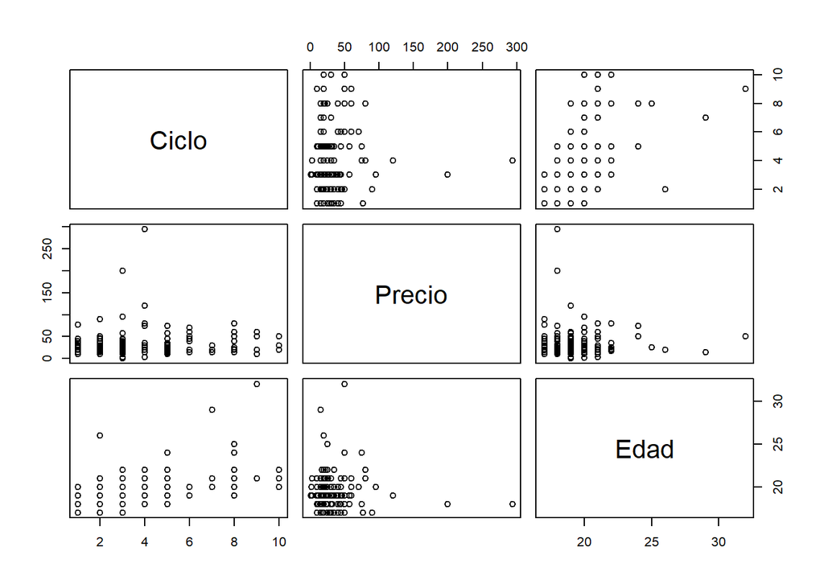

```r
pairs(~Ciclo + Precio + Edad)
```

```r
library(psych)
```

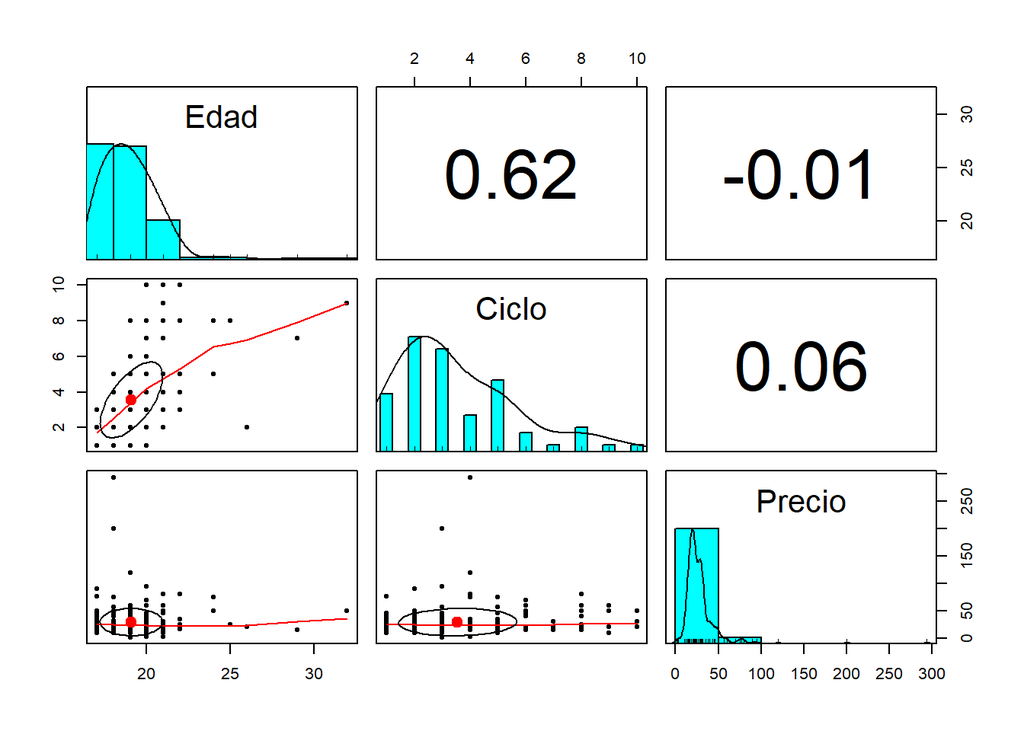

```r
pairs.panels(CA[c(2,4,16)])
```

[figure not shown]

```r
plot(Edad ~ Precio, main="Diagrama de Dispersión y correlación entre las variables Precio y Ciclo",
     xlab="Precio", ylab="Ciclo")
# Para crear una línea de regresión
abline(lm(Edad ~ Precio))
```

[figure not shown]

```r
plot(MiliS ~ Precio, main="Diagrama de Dispersión y correlación entre las variables Precio y Ciclo",
     xlab="Precio", ylab="Ciclo")
# Para crear una línea de regresión
abline(lm(MiliS ~ Precio))
```

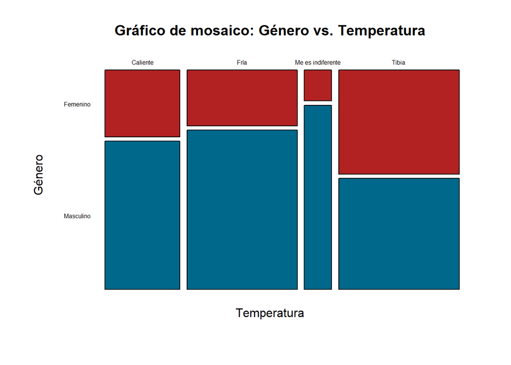

```r
mosaicplot(CA$Temperatura~CA$Genero,col=c("firebrick","deepskyblue4"),
           main="Gráfico de mosaico: Género vs. Temperatura",
           xlab="Temperatura",
           ylab="Género",
           cex.axis=0.5,
           las=1)
```

[figure not shown]

```r
mosaicplot(CA$SiliC~CA$Genero,col=c("firebrick","deepskyblue4"),
           main="Gráfico de mosaico: Género vs. Temperatura",
           xlab="Temperatura",
           ylab="Género",
           cex.axis=0.5,
           las=1)
```

[figure not shown]

```r
mosaicplot(CA$Sal~CA$Genero,col=c("firebrick","deepskyblue4"),
           main="Gráfico de mosaico: Género vs. Temperatura",
           xlab="Temperatura",
           ylab="Género",
           cex.axis=0.5,
           las=1)
```

[figure not shown]

```r
mosaicplot(CA$Sulfatos~CA$Genero,col=c("firebrick","deepskyblue4"),
           main="Gráfico de mosaico: Género vs. Temperatura",
           xlab="Temperatura",
           ylab="Género",
           cex.axis=0.5,
           las=1)
```

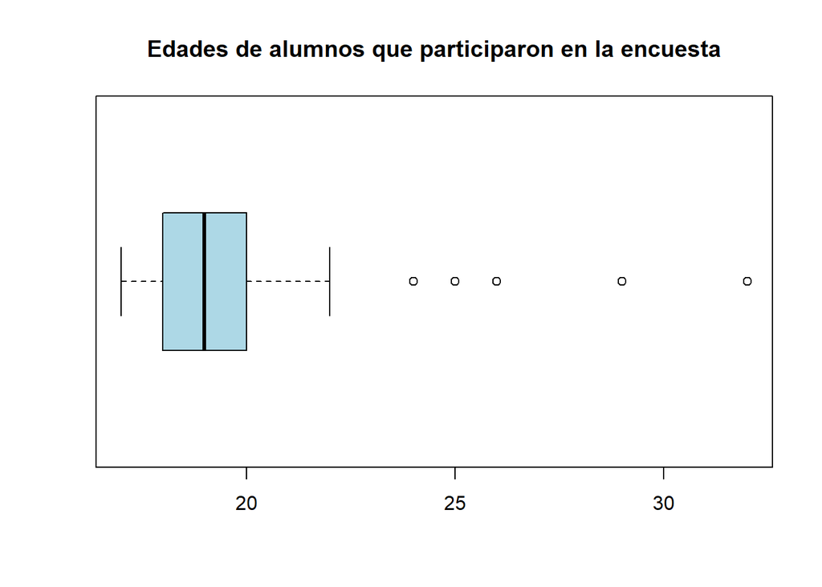

```r
boxplot(CA$Edad, main="Edades de alumnos que participaron en la encuesta",col="lightblue",horizontal = T)
```

#### Diagramas de dispersión:

**Para las variables Edad y Precio**

Primero para tener una posible idea de la relación debemos de realizar el siguiente gráfico de dispersión:

En primera instancia observamos que no hay una correlación

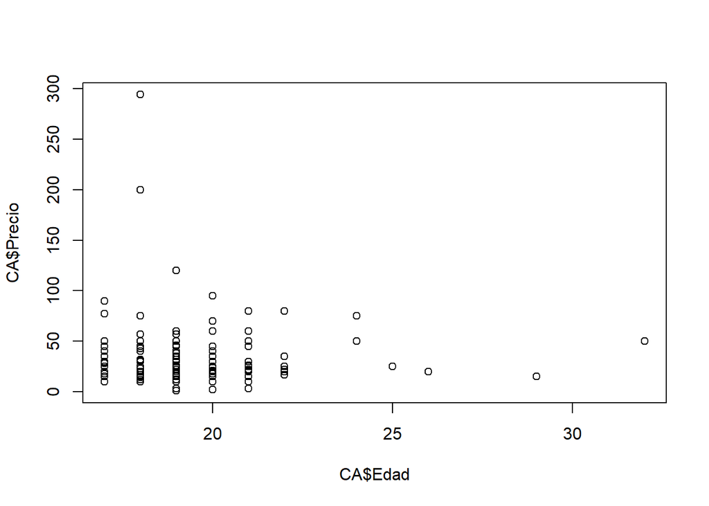

```r
plot(CA$Edad,CA$Precio)
```

[figure not shown]

[figure not shown]

```r
summary(lm(CA$Precio~CA$Edad))
```

```
##
## Call:
## lm(formula = CA$Precio ~ CA$Edad)
##
## Residuals:
##     Min      1Q  Median      3Q     Max
## -28.485  -9.585  -4.585   0.615 264.415
##
## Coefficients:
##             Estimate Std. Error t value Pr(>|t|)
## (Intercept) 31.38243   16.17652   1.940   0.0535 .
## CA$Edad     -0.09986    0.84356  -0.118   0.9059
## ---
## Signif. codes:  0 '***' 0.001 '**' 0.01 '*' 0.05 '.' 0.1 ' ' 1
##
## Residual standard error: 25.11 on 254 degrees of freedom
##   (1 observation deleted due to missingness)
## Multiple R-squared:  5.517e-05,  Adjusted R-squared:  -0.003882
## F-statistic: 0.01401 on 1 and 254 DF,  p-value: 0.9059
```

También observamos que no existe coeficiente de correlación:

```r
cor(CA$Edad, CA$Precio)
```

```
## [1] NA
```

**Para las variables VecesC y Precio** Primero para tener una posible idea de la relación debemos de realizar el siguiente gráfico de dispersión Observamos que al parecer no existe una relación:

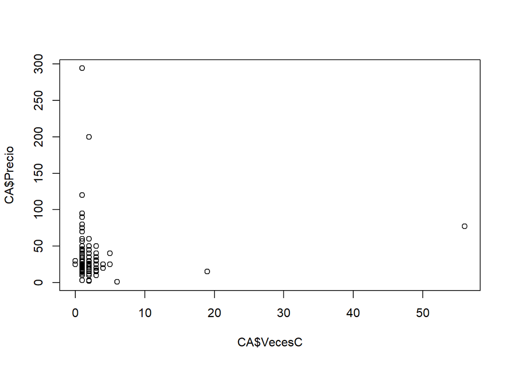

```r
plot(CA$VecesC,CA$Precio)
```

[figure not shown]

```r
summary(lm(CA$Precio~CA$VecesC))
```

```
##
## Call:
## lm(formula = CA$Precio ~ CA$VecesC)
##
## Residuals:
##     Min      1Q  Median      3Q     Max
## -30.815  -9.616  -4.616   0.934 264.934
##
## Coefficients:
##             Estimate Std. Error t value Pr(>|t|)
## (Intercept)  28.5166     1.7333  16.452   <2e-16 ***
## CA$VecesC     0.5498     0.4275   1.286      0.2
## ---
## Signif. codes:  0 '***' 0.001 '**' 0.01 '*' 0.05 '.' 0.1 ' ' 1
##
## Residual standard error: 25.03 on 254 degrees of freedom
##   (1 observation deleted due to missingness)
## Multiple R-squared:  0.00647,    Adjusted R-squared:  0.002559
## F-statistic: 1.654 on 1 and 254 DF,  p-value: 0.1996
```

También observamos que no existe coeficiente de correlación:

```r
cor(CA$VecesC, CA$Precio)
```

```
## [1] NA
```

### Escala vs precio del shampoo

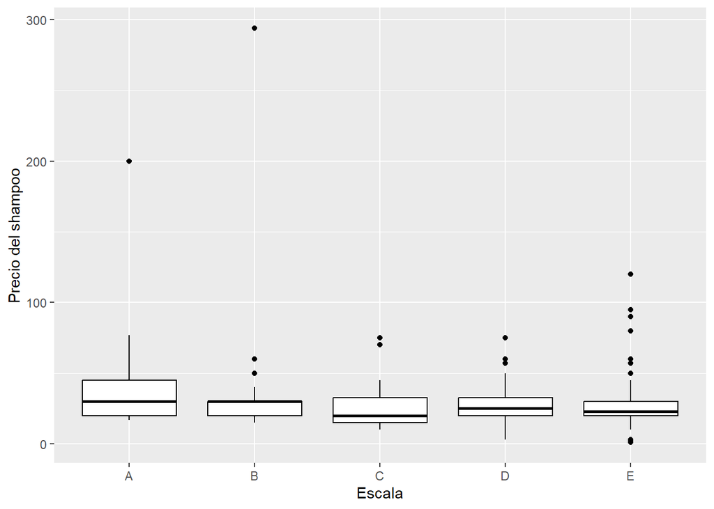

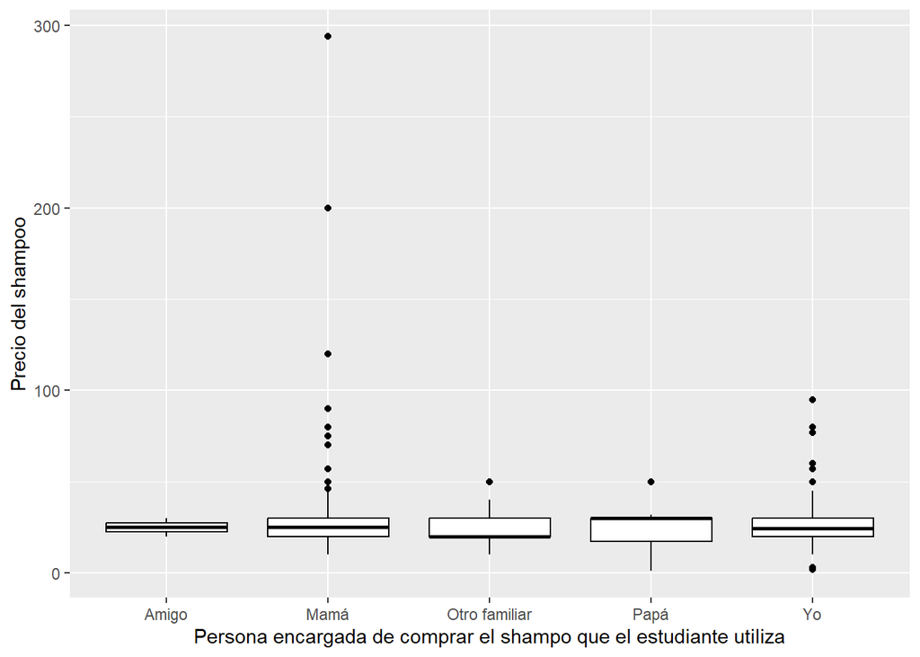

[figure not shown]

```r
summary(lm(CA$Precio~CA$Escala))
```

```
##
## Call:
## lm(formula = CA$Precio ~ CA$Escala)
##
## Residuals:
##     Min      1Q  Median      3Q     Max
## -32.000 -11.103  -5.853   3.147 251.842
##
## Coefficients:
##             Estimate Std. Error t value Pr(>|t|)
## (Intercept)   49.000      7.414   6.609 2.31e-10 ***
## CA$EscalaB    -6.842      9.317  -0.734  0.46340
## CA$EscalaC   -20.312      9.632  -2.109  0.03594 *
## CA$EscalaD   -19.851      8.237  -2.410  0.01667 *
## CA$EscalaE   -22.147      7.661  -2.891  0.00418 **
## ---
## Signif. codes:  0 '***' 0.001 '**' 0.01 '*' 0.05 '.' 0.1 ' ' 1
##
## Residual standard error: 24.59 on 251 degrees of freedom
##   (1 observation deleted due to missingness)
## Multiple R-squared:  0.05235,    Adjusted R-squared:  0.03725
## F-statistic: 3.467 on 4 and 251 DF,  p-value: 0.008876
```

```r
library(gridExtra)
```

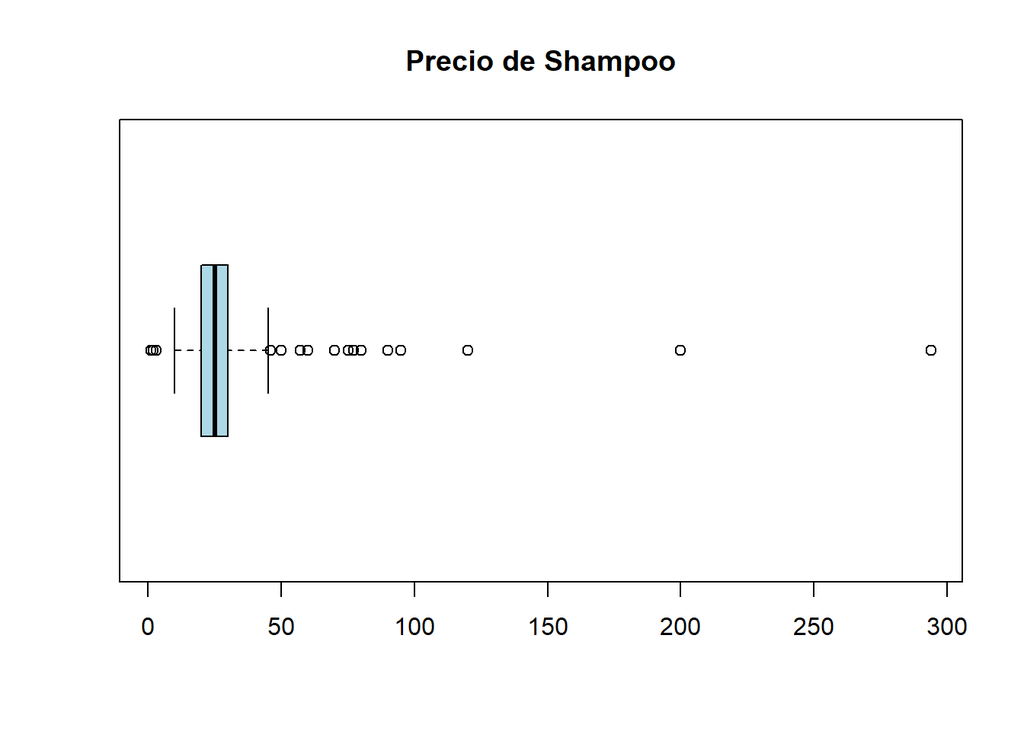

```r
boxplot(CA$Precio, main="Precio de Shampoo",col="lightblue",horizontal = T)
```

```r
summary(CA$Precio)
```

```
##    Min. 1st Qu.  Median    Mean 3rd Qu.    Max.    NA's
##    1.00   20.00   25.00   29.48   30.00  294.00       1
```

#### Productos

```r
CA$Precio<-as.numeric(CA$Precio)
CA$Edad<-as.numeric(CA$Edad)
```

```r
str(CA)
```

```
## tibble [257 x 33] (S3: tbl_df/tbl/data.frame)
##  $ Genero                    : chr [1:257] "Femenino" "Masculino" "Masculino" "Femenino" ...
##  $ Edad                      : num [1:257] 21 21 21 20 20 20 18 18 18 18 ...
##  $ Carrera                   : chr [1:257] "Bioingeniería" "Ing. Civil" "Ing. Industrial" "Ing. Civil" ...
##  $ Ciclo                     : num [1:257] 4 3 4 3 3 6 4 4 4 2 ...
##  $ Escala                    : chr [1:257] "E" "E" "E" "E" ...
##  $ Longitud                  : chr [1:257] "Mediano" "Corto" "Corto" "Largo" ...
##  $ Tipo                      : chr [1:257] "Graso" "Mixto" "Mixto" "Seco" ...
##  $ LavaC                     : chr [1:257] "Interdiario" "Diario" "Interdiario" "Interdiario" ...
##  $ MiliS                     : num [1:257] 1 3 3 5 3 5 5 1 4 2 ...
##  $ Temperatura               : chr [1:257] "Tibia" "Fría" "Fría" "Caliente" ...
##  $ Tiempo                    : num [1:257] 100 6 10 30 10 5 10 10 120 30 ...
##  $ VecesC                    : num [1:257] 1 1 1 1 1 1 0 1 1 3 ...
##  $ Sulfatos                  : chr [1:257] "No" "No sé" "No sé" "No" ...
##  $ Sal                       : chr [1:257] "No" "No sé" "No sé" "No" ...
```

[output cut: 19 more lines]

```r
CA%>%count(Acondicionador)
```

```
## # A tibble: 2 x 2
##   Acondicionador     n
##   <chr>          <int>
## 1 No               116
## 2 Sí               141
```

```r
CA%>%count(Mascarilla_para_el_cabello)
```

```
## # A tibble: 2 x 2
##   Mascarilla_para_el_cabello     n
##   <chr>                      <int>
## 1 No                           215
## 2 Sí                            42
```

```r
CA%>%count(Gel)
```

```
## # A tibble: 2 x 2
##   Gel       n
##   <chr> <int>
## 1 No      216
## 2 Sí       41
```

```r
CA%>%count(Crema_para_peinar)
```

```
## # A tibble: 2 x 2
##   Crema_para_peinar     n
##   <chr>             <int>
## 1 No                  187
## 2 Sí                   70
```

```r
CA%>%count(Serum)
```

```
## # A tibble: 2 x 2
##   Serum     n
##   <chr> <int>
## 1 No      241
## 2 Sí       16
```

```r
CA%>%count(otros)
```

```
## # A tibble: 2 x 2
##   otros     n
##   <chr> <int>
## 1 No      236
## 2 Sí       21
```

```r
library(tidyverse)
library(scales)
```

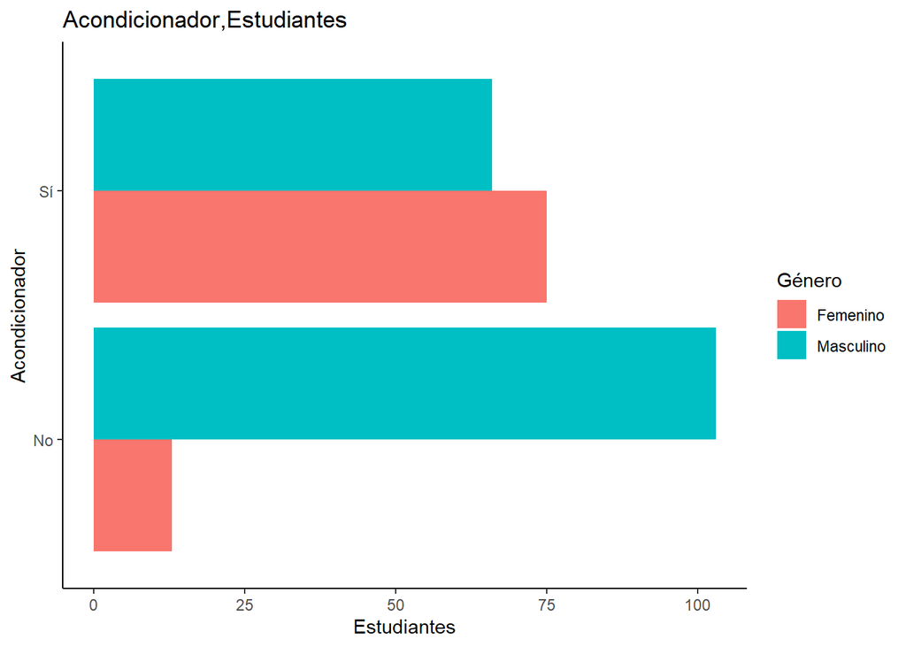

```r
CA_acondicionador<- CA%>% count(Acondicionador)%>%
  mutate(prop=n/sum(n))

acondi_genero<-CA%>%
  filter(Genero!="No especificado")%>%
  group_by(Genero)%>%
  count(Acondicionador)%>%
  mutate(prop=n/sum(n))

ggplot(acondi_genero,aes(Acondicionador,n,fill=Genero))+
  geom_bar(stat="identity",position="dodge")+
  labs(x="Acondicionador",
       y="Estudiantes",
       title = "Acondicionador,Estudiantes",
       fill="Género")+
  theme_classic()+
  coord_flip()
```

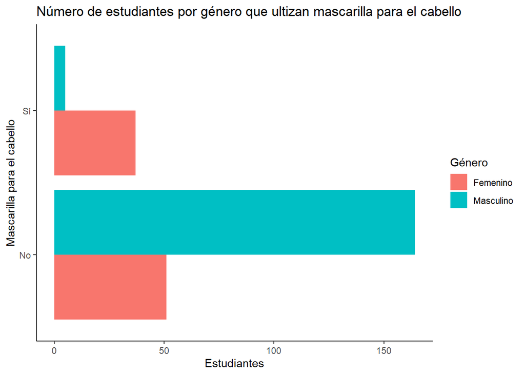

```r
CA_masc<- CA%>% count(Mascarilla_para_el_cabello)%>%
  mutate(prop=n/sum(n))

masc_genero<-CA%>%
  filter(Genero!="No especificado")%>%
  group_by(Genero)%>%
  count(Mascarilla_para_el_cabello)%>%
  mutate(prop=n/sum(n))

ggplot(masc_genero,aes(Mascarilla_para_el_cabello,n,fill=Genero))+
  geom_bar(stat="identity",position="dodge")+
  labs(x="Mascarilla para el cabello",
       y="Estudiantes",
       title = "Número de estudiantes por género que ultizan mascarilla para el cabello",
       fill="Género")+
  theme_classic()+
  coord_flip()
```

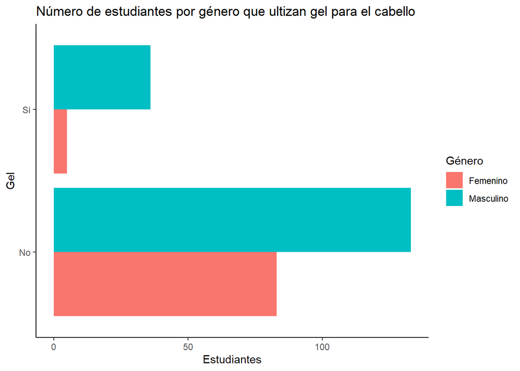

```r
CA_gel<- CA%>% count(Gel)%>%
  mutate(prop=n/sum(n))

gel_genero<-CA%>%
  filter(Genero!="No especificado")%>%
  group_by(Genero)%>%
  count(Gel)%>%
  mutate(prop=n/sum(n))

ggplot(gel_genero,aes(Gel,n,fill=Genero))+
  geom_bar(stat="identity",position="dodge")+
  labs(x="Gel",
       y="Estudiantes",
       title = "Número de estudiantes por género que ultizan gel para el cabello",
       fill="Género")+
  theme_classic()+
  coord_flip()
```

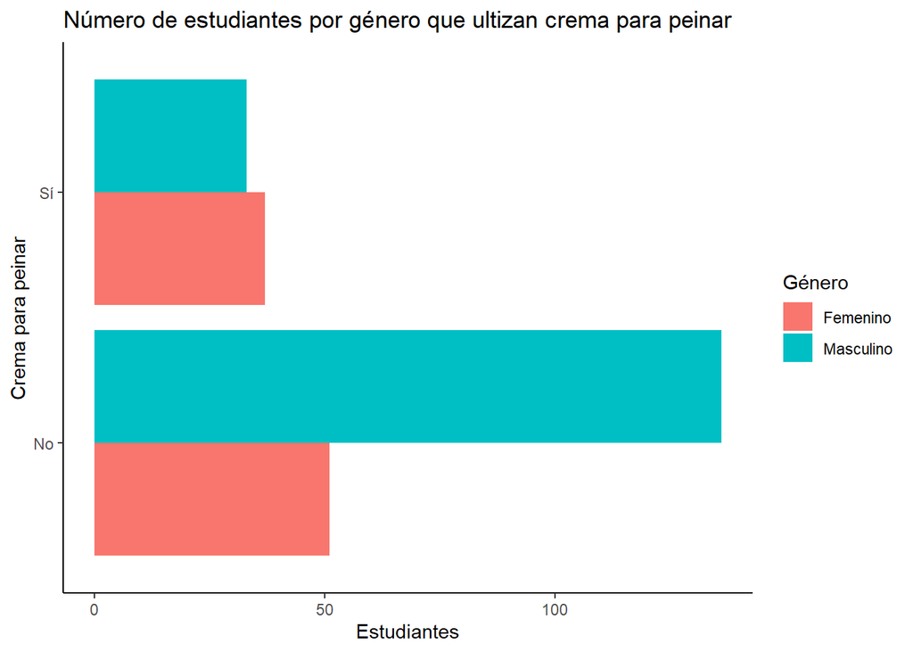

```r
CA_crema<- CA%>% count(Crema_para_peinar)%>%
  mutate(prop=n/sum(n))

crema_genero<-CA%>%
  filter(Genero!="No especificado")%>%
  group_by(Genero)%>%
  count(Crema_para_peinar)%>%
  mutate(prop=n/sum(n))

ggplot(crema_genero,aes(Crema_para_peinar,n,fill=Genero))+
  geom_bar(stat="identity",position="dodge")+
  labs(x="Crema para peinar",
       y="Estudiantes",
       title = "Número de estudiantes por género que ultizan crema para peinar",
       fill="Género")+
  theme_classic()+
  coord_flip()
```

```r
CA%>%count(Sal)
```

```
## # A tibble: 3 x 2
##   Sal       n
##   <chr> <int>
## 1 No      106
## 2 No sé   117
## 3 Sí       34
```

```r
CA%>%count(SiliC)
```

```
## # A tibble: 3 x 2
##   SiliC     n
##   <chr> <int>
## 1 No      134
## 2 No sé   100
## 3 Sí       23
```

```r
CA%>%count(Sulfatos)
```

```
## # A tibble: 3 x 2
##   Sulfatos     n
##   <chr>    <int>
## 1 No          77
## 2 No sé      151
## 3 Sí          29
```

```r
CA%>%count(Cruelfre)
```

```
## # A tibble: 3 x 2
##   Cruelfre     n
##   <chr>    <int>
## 1 No          42
## 2 No sé      145
## 3 Sí          70
```

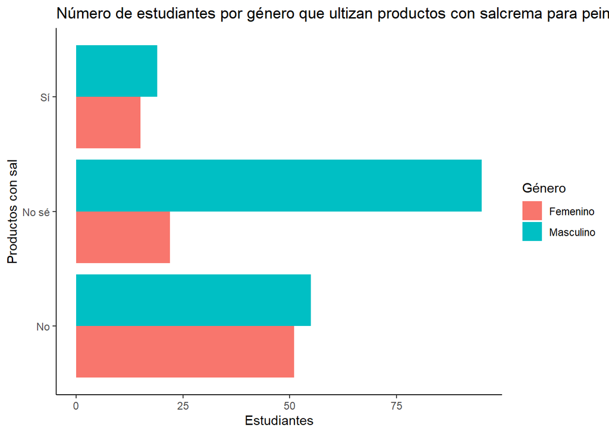

```r
CA_sal<- CA%>% count(Sal)%>%
  mutate(prop=n/sum(n))

sal_genero<-CA%>%
  filter(Genero!="No especificado")%>%
  group_by(Genero)%>%
  count(Sal)%>%
  mutate(prop=n/sum(n))

ggplot(sal_genero,aes(Sal,n,fill=Genero))+
  geom_bar(stat="identity",position="dodge")+
  labs(x="Productos con sal",
       y="Estudiantes",
       title = "Número de estudiantes por género que ultizan productos con salcrema para peinar",
       fill="Género")+
  theme_classic()+
  coord_flip()
```

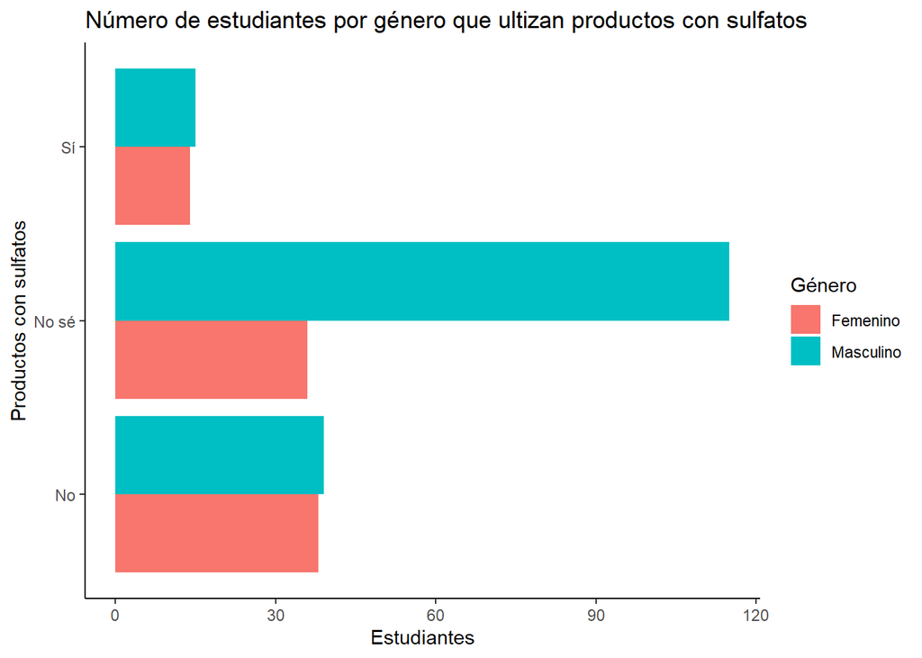

```r
CA_sulf<- CA%>% count(Sulfatos)%>%
  mutate(prop=n/sum(n))

sulf_genero<-CA%>%
  filter(Genero!="No especificado")%>%
  group_by(Genero)%>%
  count(Sulfatos)%>%
  mutate(prop=n/sum(n))

ggplot(sulf_genero,aes(Sulfatos,n,fill=Genero))+
  geom_bar(stat="identity",position="dodge")+
  labs(x="Productos con sulfatos",
       y="Estudiantes",
       title = "Número de estudiantes por género que ultizan productos con sulfatos",
       fill="Género")+
  theme_classic()+
  coord_flip()
```

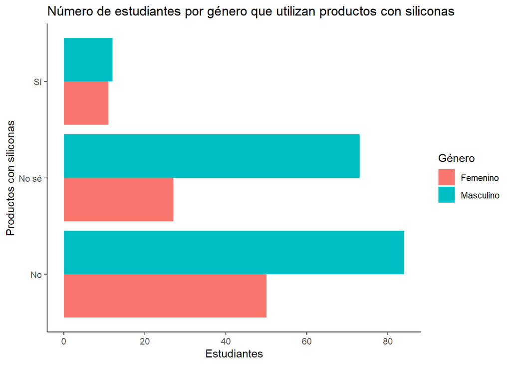

```r
CA_silic<- CA%>% count(SiliC)%>%
  mutate(prop=n/sum(n))

silic_genero<-CA%>%
  filter(Genero!="No especificado")%>%
  group_by(Genero)%>%
  count(SiliC)%>%
  mutate(prop=n/sum(n))

ggplot(silic_genero,aes(SiliC,n,fill=Genero))+
  geom_bar(stat="identity",position="dodge")+
  labs(x="Productos con siliconas",
       y="Estudiantes",
       title = "Número de estudiantes por género que utilizan productos con siliconas",
       fill="Género")+
  theme_classic()+
  coord_flip()
```

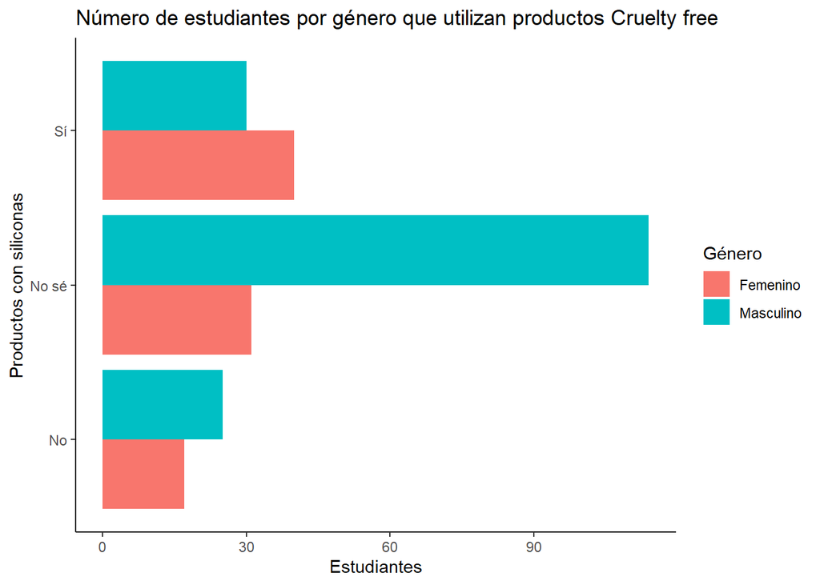

```r
CA_cruel<- CA%>% count(Cruelfre)%>%
  mutate(prop=n/sum(n))

cruel_genero<-CA%>%
  filter(Genero!="No especificado")%>%
  group_by(Genero)%>%
  count(Cruelfre)%>%
  mutate(prop=n/sum(n))

ggplot(cruel_genero,aes(Cruelfre,n,fill=Genero))+
  geom_bar(stat="identity",position="dodge")+
  labs(x="Productos con siliconas",
       y="Estudiantes",
       title = "Número de estudiantes por género que utilizan productos Cruelty free",
       fill="Género")+
  theme_classic()+
  coord_flip()
```

```r
str(CA)
```

```
## tibble [257 x 33] (S3: tbl_df/tbl/data.frame)
##  $ Genero                    : chr [1:257] "Femenino" "Masculino" "Masculino" "Femenino" ...
##  $ Edad                      : num [1:257] 21 21 21 20 20 20 18 18 18 18 ...
##  $ Carrera                   : chr [1:257] "Bioingeniería" "Ing. Civil" "Ing. Industrial" "Ing. Civil" ...
##  $ Ciclo                     : num [1:257] 4 3 4 3 3 6 4 4 4 2 ...
##  $ Escala                    : chr [1:257] "E" "E" "E" "E" ...
##  $ Longitud                  : chr [1:257] "Mediano" "Corto" "Corto" "Largo" ...
##  $ Tipo                      : chr [1:257] "Graso" "Mixto" "Mixto" "Seco" ...
##  $ LavaC                     : chr [1:257] "Interdiario" "Diario" "Interdiario" "Interdiario" ...
##  $ MiliS                     : num [1:257] 1 3 3 5 3 5 5 1 4 2 ...
##  $ Temperatura               : chr [1:257] "Tibia" "Fría" "Fría" "Caliente" ...
##  $ Tiempo                    : num [1:257] 100 6 10 30 10 5 10 10 120 30 ...
##  $ VecesC                    : num [1:257] 1 1 1 1 1 1 0 1 1 3 ...
##  $ Sulfatos                  : chr [1:257] "No" "No sé" "No sé" "No" ...
##  $ Sal                       : chr [1:257] "No" "No sé" "No sé" "No" ...
```

[output cut: 19 more lines]

```r
CA%>%count(Cruelfre)
```

```
## # A tibble: 3 x 2
##   Cruelfre     n
##   <chr>    <int>
## 1 No          42
## 2 No sé      145
## 3 Sí          70
```

```r
CA%>%count(Carrera)
```

```
## # A tibble: 11 x 2
##    Carrera                       n
##    <chr>                     <int>
##  1 Bioingeniería                36
##  2 Ciencia de Datos              5
##  3 Ciencia de la Computación    35
##  4 Ing. Ambiental               25
##  5 Ing. Civil                   40
##  6 Ing. Electrónica             13
##  7 Ing. Industrial              28
##  8 Ing. Mecatrónica             39
##  9 Ing. Mecánica                18
## 10 Ing. Química                 14
## 11 Ing. de la Energía            4
```

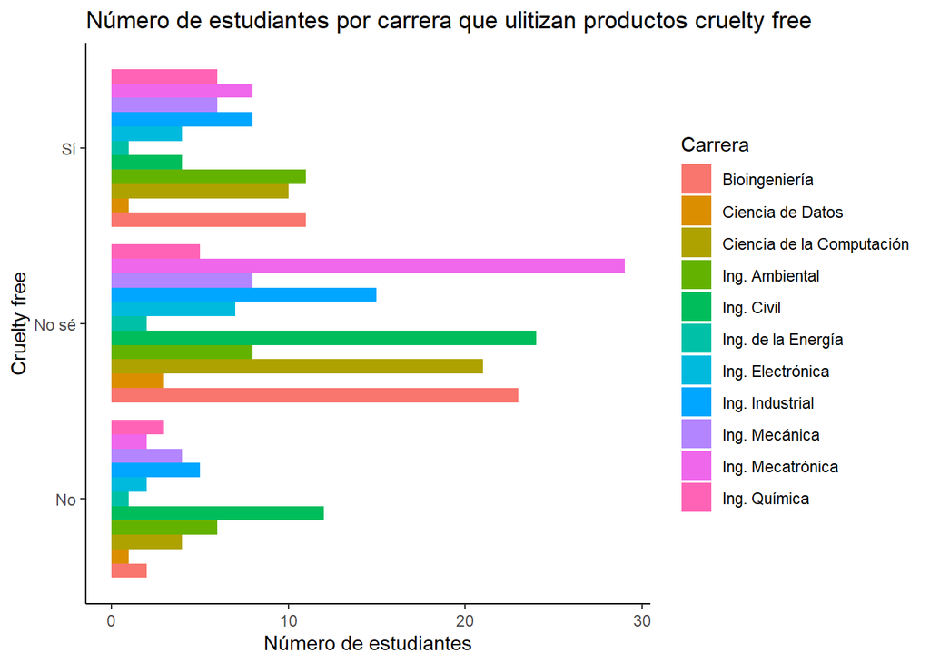

```r
CA_Cruelfre<- CA%>% count(Cruelfre)%>%
  mutate(prop=n/sum(n))

cruel_carrera<-CA%>%
  filter(Carrera!="No especificado")%>%
  group_by(Carrera)%>%
  count(Cruelfre)%>%
  mutate(prop=n/sum(n))

ggplot(cruel_carrera,aes(Cruelfre,n,fill=Carrera))+
  geom_bar(stat="identity",position="dodge")+
  labs(x="Cruelty free",
       y="Número de estudiantes",
       title = "Número de estudiantes por carrera que ulitizan productos cruelty free",
       fill="Carrera")+
  theme_classic()+
  coord_flip()
```

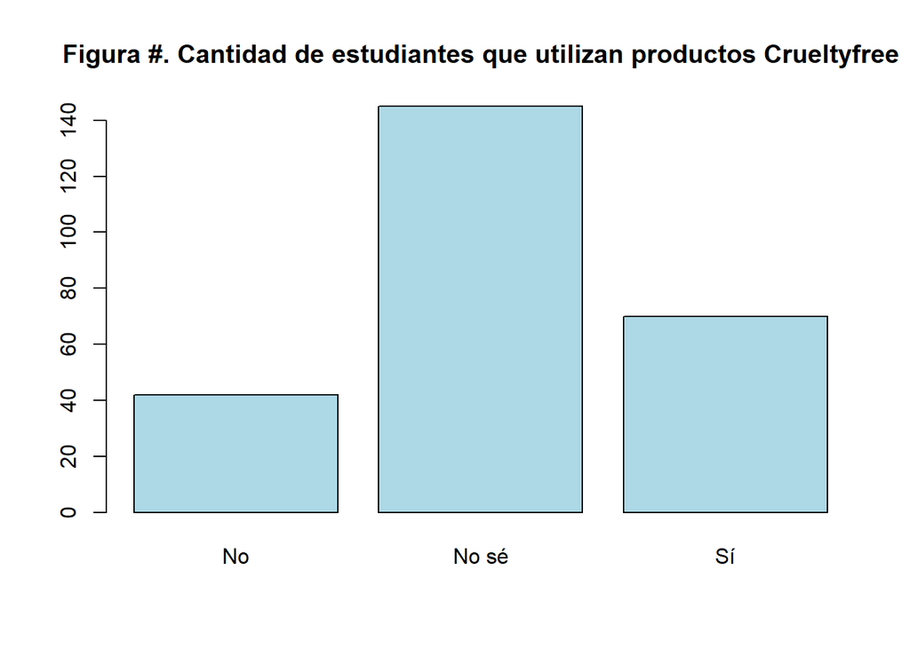

```r
plot(as.factor(CA$Cruelfre), main = "Figura #. Cantidad de estudiantes que utilizan productos Crueltyfree", col="lightblue")
```

```r
CA%>%count(Plancha)
```

```
## # A tibble: 2 x 2
##   Plancha     n
##   <chr>   <int>
## 1 No        228
## 2 Sí         29
```

```r
CA%>%count(Secador)
```

```
## # A tibble: 2 x 2
##   Secador     n
##   <chr>   <int>
## 1 No        194
## 2 Sí         63
```

```r
CA%>%count(Rizador)
```

```
## # A tibble: 2 x 2
##   Rizador     n
##   <chr>   <int>
## 1 No        247
## 2 Sí         10
```

```r
CA%>%count(OtrasHerr)
```

```
## # A tibble: 2 x 2
##   OtrasHerr     n
##   <chr>     <int>
## 1 No          247
## 2 Sí           10
```

```r
CA%>%count(No_utilizoHerr)
```

```
## # A tibble: 2 x 2
##   No_utilizoHerr     n
##   <chr>          <int>
## 1 No                83
## 2 Sí               174
```

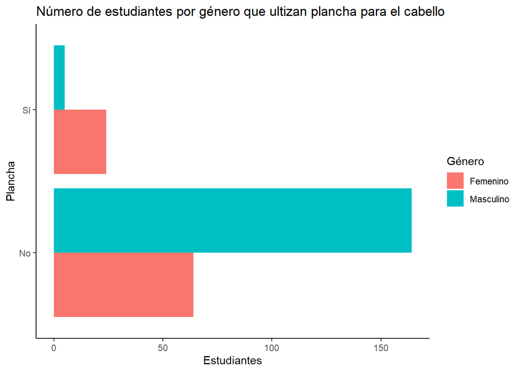

```r
CA_plancha<- CA%>% count(Plancha)%>%
  mutate(prop=n/sum(n))

plancha_genero<-CA%>%
  filter(Genero!="No especificado")%>%
  group_by(Genero)%>%
  count(Plancha)%>%
  mutate(prop=n/sum(n))

ggplot(plancha_genero,aes(Plancha,n,fill=Genero))+
  geom_bar(stat="identity",position="dodge")+
  labs(x="Plancha",
       y="Estudiantes",
       title = "Número de estudiantes por género que ultizan plancha para el cabello",
       fill="Género")+
  theme_classic()+
  coord_flip()
```

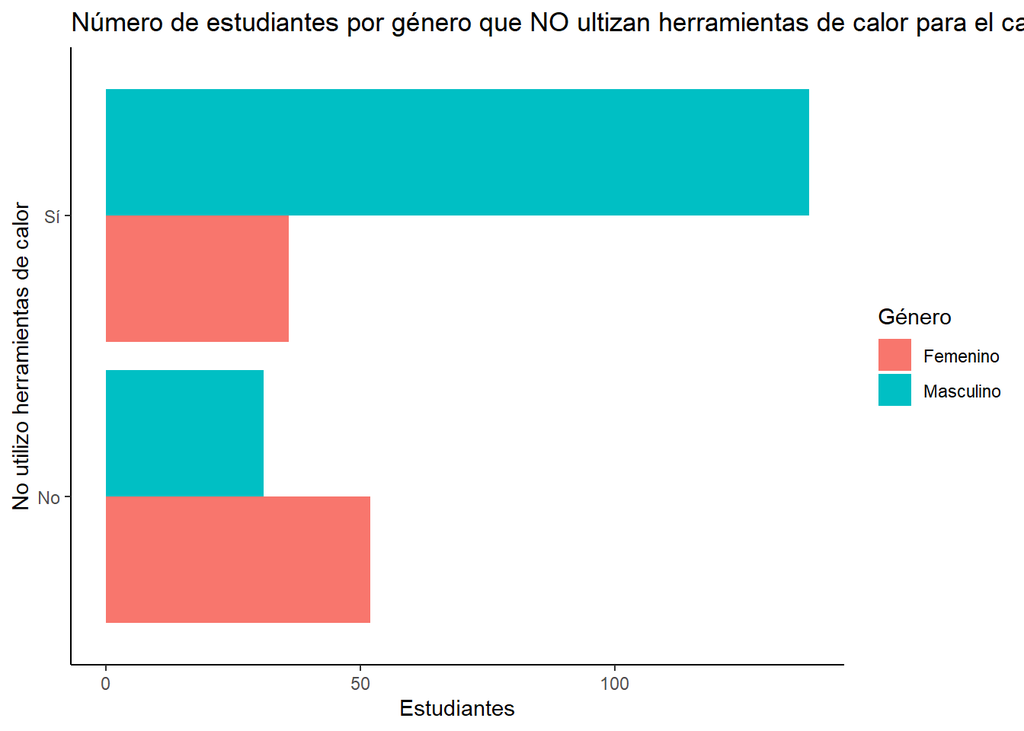

```r
CA_NoUtilHerr<- CA%>% count(No_utilizoHerr)%>%
  mutate(prop=n/sum(n))

NoUtilHerr_genero<-CA%>%
  filter(Genero!="No especificado")%>%
  group_by(Genero)%>%
  count(No_utilizoHerr)%>%
  mutate(prop=n/sum(n))

ggplot(NoUtilHerr_genero,aes(No_utilizoHerr,n,fill=Genero))+
  geom_bar(stat="identity",position="dodge")+
  labs(x="No utilizo herramientas de calor",
       y="Estudiantes",
       title = "Número de estudiantes por género que NO ultizan herramientas de calor para el cabello",
       fill="Género")+
  theme_classic()+
  coord_flip()
```

[figure not shown]

```r
CA_secador<- CA%>% count(Secador)%>%
  mutate(prop=n/sum(n))

secador_genero<-CA%>%
  filter(Genero!="No especificado")%>%
  group_by(Genero)%>%
  count(Secador)%>%
  mutate(prop=n/sum(n))

ggplot(secador_genero,aes(Secador,n,fill=Genero))+
  geom_bar(stat="identity",position="dodge")+
  labs(x="Sacador",
       y="Estudiantes",
       title = "Número de estudiantes por género que ultizan gel para el cabello",
       fill="Género")+
  theme_classic()+
  coord_flip()
```

## **7. Análisis probabilístico**

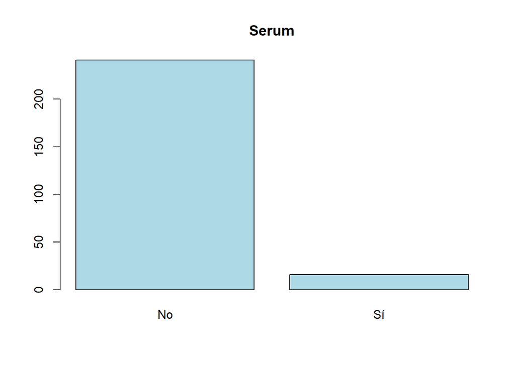

```r
plot(as.factor(CA$Serum), main = "Serum", col="lightblue")
```

```r
SerumTable <- table(as.factor(CA$Serum))
ProbSerum <- SerumTable/nrow(CA)
ProbSerum
```

```
##
##         No         Sí
## 0.93774319 0.06225681
```

Probabilidad aproximada de que los estudiantes utilicen serum: 0.06 Probabilidad aproximada de que los estudiantes NO utilicen serum: 0.94

Si se selecciona una muestra de 30 estudiantes al azar ¿Cuál es la probabilidad de que 12 de los estudiantes seleccionados utilice serum?

```r
dbinom(12,30,0.06)
```

```
## [1] 6.181565e-08
```

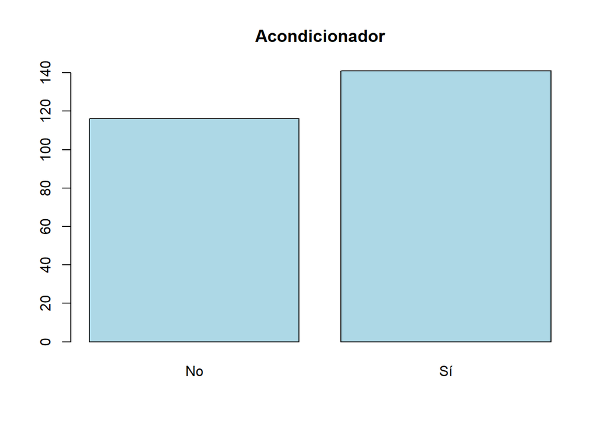

```r
plot(as.factor(CA$Acondicionador), main = "Acondicionador", col="lightblue")
```

```r
AcondiTable <- table(as.factor(CA$Acondicionador))
ProbAcondi <- AcondiTable/nrow(CA)
ProbAcondi
```

```
##
##        No        Sí
## 0.4513619 0.5486381
```

Probabilidad aproximada de que los estudiantes utilicen acondicionador: 0.54 Probabilidad aproximada de que los estudiantes NO utilicen acondicionador: 0.45

Si se selecciona una muestra de 10 estudiantes al azar ¿Cuál es la probabilidad de que 4 de los estudiantes seleccionados utilice acondiconador?

```r
dbinom(4,10,0.54)
```

```
## [1] 0.169177
```

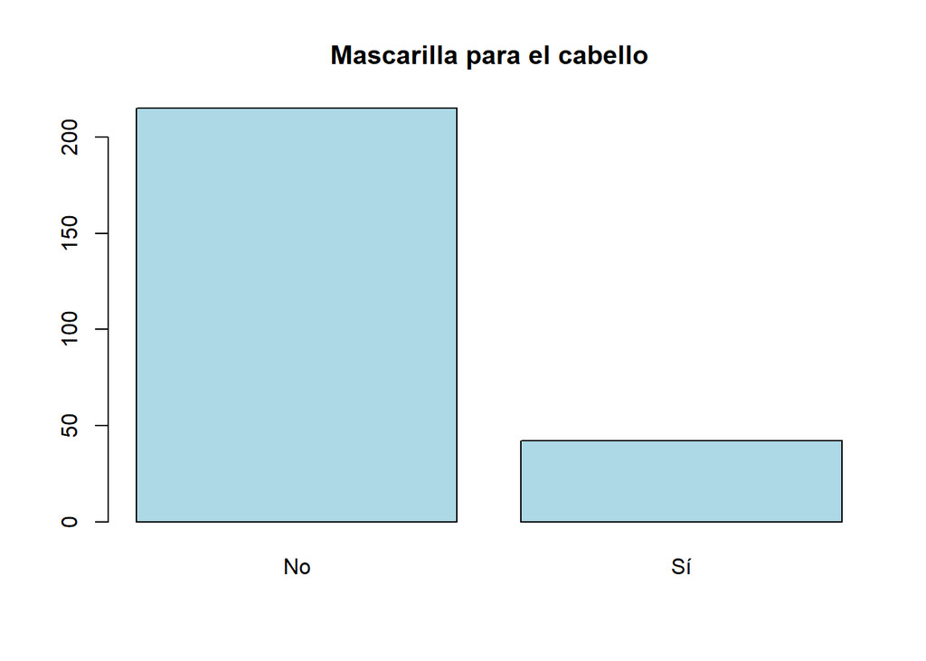

```r
plot(as.factor(CA$Mascarilla_para_el_cabello), main = "Mascarilla para el cabello", col="lightblue")
```

```r
MascTable <- table(as.factor(CA$Mascarilla_para_el_cabello))
ProbMasc <- MascTable/nrow(CA)
ProbMasc
```

```
##
##        No        Sí
## 0.8365759 0.1634241
```

Si se selecciona una muestra de 10 estudiantes al azar ¿Cuál es la probabilidad de que 4 de los estudiantes seleccionados utilice acondiconador?

```r
dbinom(4,10,0.54)
```

```
## [1] 0.169177
```

## **8. Modelos probabilísticos**

```r
library(DescTools)
library(raster)
```

**Medidas de tendencia central:**

Para la variable Precio:

```r
mean(CA$Precio)
```

```
## [1] NA
```

```r
median(CA$Precio)
```

```
## [1] NA
```

```r
Mode(CA$Precio)
```

```
## [1] NA
## attr(,"freq")
## [1] NA
```

Para la variable Milis:

```r
mean(CA$MiliS)
```

```
## [1] 2.867704
```

```r
median(CA$MiliS)
```

```
## [1] 3
```

```r
Mode(CA$MiliS)
```

```
## [1] 3
## attr(,"freq")
## [1] 80
```

Para la variable Precio y Género:

```r
tapply(CA$Precio,CA$Genero,mean)
```

```
##  Femenino Masculino
##  34.30682        NA
```

```r
tapply(CA$Precio,CA$Genero,median)
```

```
##  Femenino Masculino
##        30        NA
```

```r
tapply(CA$Precio,CA$Genero,Mode)
```

```
##  Femenino Masculino
##        30        NA
```

Para la variable Tipo y VecesC:

```r
tapply(CA$VecesC,CA$Tipo,mean)
```

```
##    Graso    Mixto     Seco
## 1.804348 1.425373 2.272727
```

```r
tapply(CA$VecesC,CA$Tipo,median)
```

```
## Graso Mixto  Seco
##     1     1     1
```

```r
tapply(CA$VecesC,CA$Tipo,Mode)
```

```
## Graso Mixto  Seco
##     1     1     1
```

Ahora podemos observar que en una vista general los estudiantes prefieren lavarse el cabello con agua tibia, pero de forma específica el género femenino prefiere lavarse con agua Tibia y el género masculino prefiere lavarse con agua fría:

```r
mfv(CA$Temperatura)
```

```
## [1] "Tibia"
```

```r
table(CA$Temperatura,CA$Genero)
```

```
##
##                     Femenino Masculino
##   Caliente                18        40
##   Fría                    22        63
##   Me es indiferente        3        18
##   Tibia                   45        48
```

**Medidas de tendencia no central:**

```r
summary(CA$Precio)
```

```
##    Min. 1st Qu.  Median    Mean 3rd Qu.    Max.    NA's
##    1.00   20.00   25.00   29.48   30.00  294.00       1
```

```r
summary(CA$Tiempo)
```

```
##    Min. 1st Qu.  Median    Mean 3rd Qu.    Max.    NA's
##    1.00   10.00   20.00   39.83   41.25  775.00       1
```

**Distribución normal**

```r
r <- function(x){
  return(round(x,2))
}
```

##### Función de descriptores numéricos

```r
descpNumericos<-function(datosD,alfa=0.05){
  media_=r(mean(datosD))
  mediana_=r(median(datosD))
  desEst_=r(sd(datosD))
  var_=r(desEst_^2)

  m1<-r( media_ - (qt(1-alfa/2,length(datosD)-1)*(desEst_/sqrt(length(datosD)))))
  m2<-r( media_ + (qt(1-alfa/2,length(datosD)-1)*(desEst_/sqrt(length(datosD)))))

  v1 <- r(((length(datosD)-1)*(desEst_^2))/qchisq(1-alfa/2,(length(datosD)-1)))
  v2 <- r(((length(datosD)-1)*(desEst_^2))/qchisq(alfa/2,(length(datosD)-1)))

  d1 <- r(sqrt(((length(datosD)-1)*(desEst_^2))/qchisq(1-alfa/2,(length(datosD)-1))))
  d2 <- r(sqrt(((length(datosD)-1)*(desEst_^2))/qchisq(alfa/2,(length(datosD)-1))))


  print(paste("Promedio: ",media_))
  print(paste("Intervalo de confianza del promedio: [ ",m1," : ",m2," ]"))

  print(paste("desviación estandar: ",desEst_))
  print(paste("Intervalo de confianza de la desviación estandar: [ ",d1," : ",d2," ]"))

  print(paste("Varianza: ",var_))
  print(paste("Intervalo de confianza de la varianza: [ ",v1," : ",v2," ]"))

  print(paste("Mediana: ",mediana_))

  summary(datosD)


}
```

[figure not shown]

DENSIDAD

```r
library(ggplot2)
```

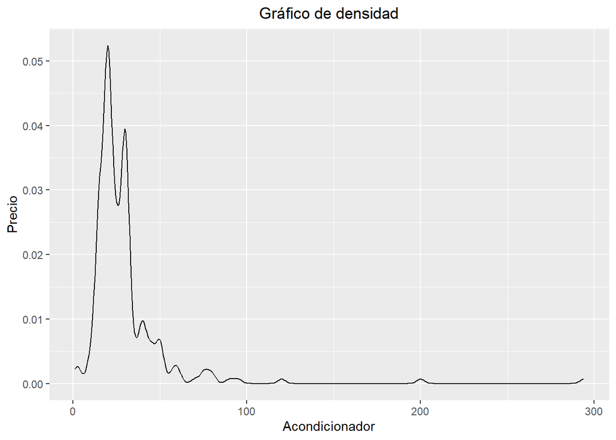

```r
densi_precio <- ggplot(data=CA)+
  aes(x=Precio)+
  geom_density()

densi_precio +
  labs(title="Gráfico de densidad",
       x="Acondicionador",
       y= "Precio")+
  theme(plot.title = element_text(hjust=0.5),
        plot.subtitle = element_text(hjust=0.5),
        plot.caption = element_text(hjust=0.5))
```

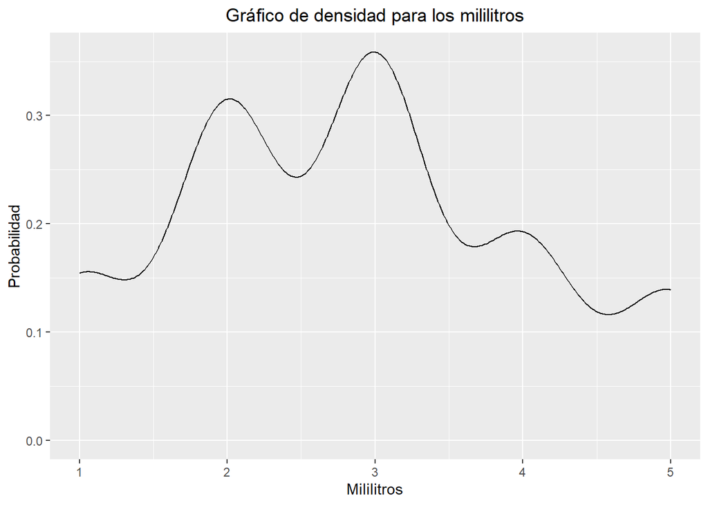

```r
densi_mili <- ggplot(data=CA)+
  aes(x=MiliS)+
  geom_density()

densi_mili +
  labs(title="Gráfico de densidad para los mililitros",
       x="Mililitros",
       y= "Probabilidad")+
  theme(plot.title = element_text(hjust=0.5),
        plot.subtitle = element_text(hjust=0.5),
        plot.caption = element_text(hjust=0.5))
```

La probabilidad de que los estudiantes utecsinos utilicen 3 mL de shampoo es

```r
dbinom(3,257,0.31)
```

```
## [1] 9.734556e-37
```

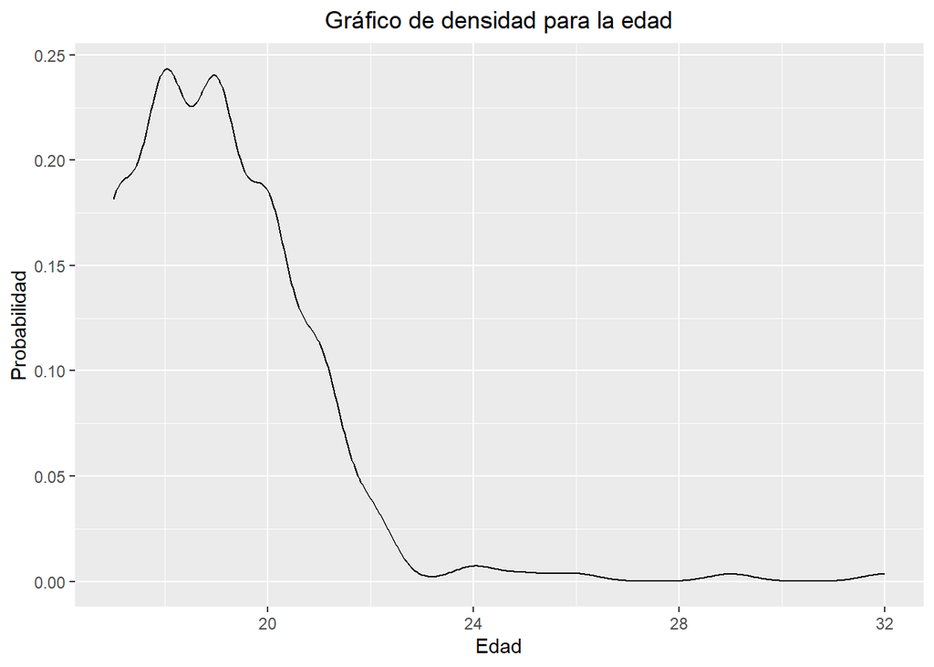

```r
densi_edad <- ggplot(data=CA)+
  aes(x=Edad)+
  geom_density()

densi_edad +
  labs(title="Gráfico de densidad para la edad",
       x="Edad",
       y= "Probabilidad")+
  theme(plot.title = element_text(hjust=0.5),
        plot.subtitle = element_text(hjust=0.5),
        plot.caption = element_text(hjust=0.5))
```

La probabilidad de que un los estudiantes utecsinos de entre 18 y 20 años sean entrevistados es

```r
pbinom(20, 257, 0.225) - pbinom(18, 257, 0.225)
```

```
## [1] 2.521036e-10
```

[figure not shown]

```r
densi_tiempo <- ggplot(data=CA)+
  aes(x=Tiempo)+
  geom_density()

densi_tiempo +
  labs(title="Gráfico de densidad",
       x="Edad",
       y= "Probabilidad")+
  theme(plot.title = element_text(hjust=0.5),
        plot.subtitle = element_text(hjust=0.5),
        plot.caption = element_text(hjust=0.5))
```

## **9. Conclusiones y Recomendaciones**

El cabello es parte importante de nuestra presentación. Para mantenerlo en buen estado se necesitan productos adicionales con el fin de revitalizarlo y lucir un cabello saludable. Se ha podido evidenciar en este trabajo que los estudiantes no solo utilizan shampoo en el cuidado de su cabellera, como es el caso del acondicionador. Seguidamente, se ha podido determinar si ellos emplean herramientas de calor sobre el cabello. En adición a ello, se halló una correlación entre variables como precio del shampoo y el número de veces que se lava el cabello .Finalmente, se realizó unos análisis probabilísticos con la finalidad de estimar el nivel de predictibilidad de las variables escogidas respecto a los estudiantes de UTEC del ciclo 2022-2.

#### *Recomendaciones*

- Se recomienda trabajar con una muestra más grande, de manera tan que se pueda obtener una muestra representativa. Almenos se debería recolectar un 60 % de la población utecsina para determinar si existe un posible nicho de negocio de productos de cuidado del cabello.
- Debido a que el estudio fue un estudio con datos obtenidos por conveniencia, para futuras investigaciones con un alto grado de confiabilidad, se procuraría realizar un estudio aleatorio.

### **10.Bibliografía**

*Diferencias entre cabello de hombre y mujer: lo que debes saber*. (s.f.). Garnier. https://www.garnier.com.pe/tips/diferencias-entre-cabello-de-hombre-y-mujer